# Biostat 203B Homework 2

Due Feb 8 @ 11:59PM

Yenlin Lai

```r
knitr::opts_chunk$set(echo = TRUE, cache = TRUE, cache.lazy = FALSE)
library(tidyverse)
library(data.table)
library(lubridate)
```

```r
os <- sessionInfo()$running
if (str_detect(os, "Linux")) {
  mimic_path <- "/mnt/mimiciv/1.0"
} else if (str_detect(os, "macOS")) {
  mimic_path <- "/Users/huazhou/Documents/Box Sync/MIMIC/mimic-iv-1.0"
}
```

In this exercise, we use tidyverse (ggpot2, dplyr, etc) to explore the [MIMIC-IV](https://mimic.mit.edu/docs/iv/) data introduced in [homework 1](https://ucla-biostat-203b.github.io/2022winter/hw/hw1/hw1.html) and to build a cohort of ICU stays.

```r
# tree -s -L 2 /Users/huazhou/Documents/Box\ Sync/MIMIC/mimic-iv-1.0
system(str_c("tree -s -L 2 ", shQuote(mimic_path)), intern = TRUE)
```

```
##  [1] "/mnt/mimiciv/1.0"
##  [2] "├── [       4096]  core"
##  [3] "│   ├── [   17208966]  admissions.csv.gz"
##  [4] "│   ├── [        606]  index.html"
##  [5] "│   ├── [    2955582]  patients.csv.gz"
##  [6] "│   └── [   53014503]  transfers.csv.gz"
##  [7] "├── [       4096]  hosp"
##  [8] "│   ├── [     430049]  d_hcpcs.csv.gz"
##  [9] "│   ├── [   29531152]  diagnoses_icd.csv.gz"
## [10] "│   ├── [     863239]  d_icd_diagnoses.csv.gz"
## [11] "│   ├── [     579998]  d_icd_procedures.csv.gz"
## [12] "│   ├── [      14898]  d_labitems.csv.gz"
## [13] "│   ├── [   11684062]  drgcodes.csv.gz"
## [14] "│   ├── [  515763427]  emar.csv.gz"
## [15] "│   ├── [  476252563]  emar_detail.csv.gz"
```

[output cut: 26 more lines]

## Q1. `read.csv` (base R) vs `read_csv` (tidyverse) vs `fread` (data.table)

There are quite a few utilities in R for reading plain text data files. Let us test the speed of reading a moderate sized compressed csv file, `admissions.csv.gz`, by three programs: `read.csv` in base R, `read_csv` in tidyverse, and `fread` in the popular data.table package.

Which function is fastest? Is there difference in the (default) parsed data types? (Hint: R function `system.time` measures run times.)

For later questions, we stick to the tidyverse.

**Solution:**  
Use `read.csv` to read `admissions.csv.gz` and print out the system running time.

```r
system.time(data_base <- read.csv(str_c(mimic_path, "/core/admissions.csv.gz"),
                                 header = TRUE))
```

```
##    user  system elapsed
##  46.668   0.536 247.195
```

Similarly, use `read_csv` to read `admissions.csv.gz` and print out the system running time.

```r
system.time(data_tidy <- read_csv(str_c(mimic_path, "/core/admissions.csv.gz")))
```

```
##    user  system elapsed
##   3.972   0.501 245.024
```

Finally, use `fread` to read `admissions.csv.gz` and print out the system running time.

```r
system.time(data_frd <- fread(str_c(mimic_path, "/core/admissions.csv.gz")))
```

```
##    user  system elapsed
##   1.574   0.167   7.495
```

## Q2. ICU stays

`icustays.csv.gz` (https://mimic.mit.edu/docs/iv/modules/icu/icustays/) contains data about Intensive Care Units (ICU) stays. The first 10 lines are

```r
system(
  str_c(
    "zcat < ",
    shQuote(str_c(mimic_path, "/icu/icustays.csv.gz")),
    " | head"
    ),
  intern = TRUE
)
```

```
##  [1] "subject_id,hadm_id,stay_id,first_careunit,last_careunit,intime,outtime,los"
##  [2] "17867402,24528534,31793211,Trauma SICU (TSICU),Trauma SICU (TSICU),2154-03-03 04:11:00,2154-03-04 18:16:56,1.5874537037037035"
##  [3] "14435996,28960964,31983544,Trauma SICU (TSICU),Trauma SICU (TSICU),2150-06-19 17:57:00,2150-06-22 18:33:54,3.025625"
##  [4] "17609946,27385897,33183475,Trauma SICU (TSICU),Trauma SICU (TSICU),2138-02-05 18:54:00,2138-02-15 12:42:05,9.741724537037038"
##  [5] "18966770,23483021,34131444,Trauma SICU (TSICU),Trauma SICU (TSICU),2123-10-25 10:35:00,2123-10-25 18:59:47,0.35054398148148147"
##  [6] "12776735,20817525,34547665,Neuro Stepdown,Neuro Stepdown,2200-07-12 00:33:00,2200-07-13 16:44:40,1.6747685185185184"
##  [7] "10215159,24283593,34569476,Trauma SICU (TSICU),Trauma SICU (TSICU),2124-09-20 15:05:29,2124-09-21 22:06:58,1.2926967592592593"
##  [8] "14489052,26516390,35056286,Trauma SICU (TSICU),Trauma SICU (TSICU),2118-10-26 10:33:56,2118-10-26 20:28:10,0.4126620370370371"
##  [9] "15914763,28906020,36909804,Trauma SICU (TSICU),Trauma SICU (TSICU),2176-12-14 12:00:00,2176-12-17 11:47:01,2.9909837962962964"
## [10] "16256226,20013290,39289362,Neuro Stepdown,Neuro Stepdown,2150-12-20 16:09:08,2150-12-21 14:58:40,0.9510648148148149"
```

1. Import `icustatys.csv.gz` as a tibble `icustays_tble`.  
   **Solution:**

```r
icustays_tble <- read_csv((str_c(mimic_path, "/icu/icustays.csv.gz")))
```

2. How many unique `subject_id`? Can a `subject_id` have multiple ICU stays?  
   **Solution:**

```r
icustays_tble %>%
  distinct(subject_id) %>%
  nrow()
```

```
## [1] 53150
```

There are 53150 unique `subject_id`s. Since the number is smaller than the rows of this data, a `subject_id` can have multiple ICU stays.

3. For each `subject_id`, let’s only keep the first ICU stay in the tibble `icustays_tble`.  
   **Solution:**

```r
icustays_tble <-
  icustays_tble %>%
  group_by(subject_id) %>%
  filter(intime == min(intime)) %>%
  ungroup()
icustays_tble %>%
  print(width = Inf)
```

```
## # A tibble: 53,150 × 8
##    subject_id  hadm_id  stay_id first_careunit
##         <dbl>    <dbl>    <dbl> <chr>
##  1   17867402 24528534 31793211 Trauma SICU (TSICU)
##  2   14435996 28960964 31983544 Trauma SICU (TSICU)
##  3   17609946 27385897 33183475 Trauma SICU (TSICU)
##  4   18966770 23483021 34131444 Trauma SICU (TSICU)
##  5   12776735 20817525 34547665 Neuro Stepdown
##  6   10215159 24283593 34569476 Trauma SICU (TSICU)
##  7   14489052 26516390 35056286 Trauma SICU (TSICU)
##  8   15914763 28906020 36909804 Trauma SICU (TSICU)
##  9   16256226 20013290 39289362 Neuro Stepdown
## 10   19194449 21641999 39387567 Coronary Care Unit (CCU)
##    last_careunit            intime              outtime               los
##    <chr>                    <dttm>              <dttm>              <dbl>
##  1 Trauma SICU (TSICU)      2154-03-03 04:11:00 2154-03-04 18:16:56 1.59
##  2 Trauma SICU (TSICU)      2150-06-19 17:57:00 2150-06-22 18:33:54 3.03
##  3 Trauma SICU (TSICU)      2138-02-05 18:54:00 2138-02-15 12:42:05 9.74
##  4 Trauma SICU (TSICU)      2123-10-25 10:35:00 2123-10-25 18:59:47 0.351
##  5 Neuro Stepdown           2200-07-12 00:33:00 2200-07-13 16:44:40 1.67
##  6 Trauma SICU (TSICU)      2124-09-20 15:05:29 2124-09-21 22:06:58 1.29
##  7 Trauma SICU (TSICU)      2118-10-26 10:33:56 2118-10-26 20:28:10 0.413
##  8 Trauma SICU (TSICU)      2176-12-14 12:00:00 2176-12-17 11:47:01 2.99
##  9 Neuro Stepdown           2150-12-20 16:09:08 2150-12-21 14:58:40 0.951
## 10 Coronary Care Unit (CCU) 2123-11-12 02:53:35 2123-11-12 13:52:03 0.457
## # … with 53,140 more rows
```

## Q3. `admission` data

Information of the patients admitted into hospital is available in `admissions.csv.gz`. See https://mimic.mit.edu/docs/iv/modules/core/admissions/ for details of each field in this file. The first 10 lines are

```r
system(
  str_c(
    "zcat < ",
    shQuote(str_c(mimic_path, "/core/admissions.csv.gz")),
    " | head"
    ),
  intern = TRUE
)
```

```
##  [1] "subject_id,hadm_id,admittime,dischtime,deathtime,admission_type,admission_location,discharge_location,insurance,language,marital_status,ethnicity,edregtime,edouttime,hospital_expire_flag"
##  [2] "14679932,21038362,2139-09-26 14:16:00,2139-09-28 11:30:00,,ELECTIVE,,HOME,Other,ENGLISH,SINGLE,UNKNOWN,,,0"
##  [3] "15585972,24941086,2123-10-07 23:56:00,2123-10-12 11:22:00,,ELECTIVE,,HOME,Other,ENGLISH,,WHITE,,,0"
##  [4] "11989120,21965160,2147-01-14 09:00:00,2147-01-17 14:25:00,,ELECTIVE,,HOME,Other,ENGLISH,,UNKNOWN,,,0"
##  [5] "17817079,24709883,2165-12-27 17:33:00,2165-12-31 21:18:00,,ELECTIVE,,HOME,Other,ENGLISH,,OTHER,,,0"
##  [6] "15078341,23272159,2122-08-28 08:48:00,2122-08-30 12:32:00,,ELECTIVE,,HOME,Other,ENGLISH,,BLACK/AFRICAN AMERICAN,,,0"
##  [7] "19124609,20517215,2169-03-14 12:44:00,2169-03-20 19:15:00,,ELECTIVE,,HOME,Other,ENGLISH,,UNKNOWN,,,0"
##  [8] "17301855,29732723,2140-06-06 14:23:00,2140-06-08 14:25:00,,ELECTIVE,,HOME,Other,ENGLISH,,WHITE,,,0"
##  [9] "17991012,24298836,2181-07-10 20:28:00,2181-07-12 15:49:00,,ELECTIVE,,HOME,Other,ENGLISH,,WHITE,,,0"
## [10] "16865435,23216961,2185-07-19 02:12:00,2185-07-21 11:50:00,,ELECTIVE,,HOME,Other,ENGLISH,,WHITE,,,0"
```

1. Import `admissions.csv.gz` as a tibble `admissions_tble`.  
   **Solution:**

```r
admissions_tble <- read_csv((str_c(mimic_path, "/core/admissions.csv.gz")))
```

2. Let’s only keep the admissions that have a match in `icustays_tble` according to `subject_id` and `hadm_id`.  
   **Solution:**

```r
admissions_tble <-
  admissions_tble %>%
  semi_join(icustays_tble, by = c("subject_id","hadm_id"))
admissions_tble %>%
  print(width = Inf)
```

```
## # A tibble: 53,150 × 15
##    subject_id  hadm_id admittime           dischtime
##         <dbl>    <dbl> <dttm>              <dttm>
##  1   10222255 28200985 2120-11-20 20:25:00 2120-11-22 13:00:00
##  2   14485852 28712010 2113-10-31 00:23:00 2113-11-04 16:50:00
##  3   18709254 23758948 2195-10-12 01:31:00 2195-10-12 13:51:00
##  4   16837807 23526268 2151-03-19 06:09:00 2151-03-19 07:20:00
##  5   17642680 27734285 2116-05-29 12:48:00 2116-05-30 12:31:00
##  6   18230965 21251728 2142-03-12 20:00:00 2142-03-17 15:26:00
##  7   17374121 27667114 2115-07-22 07:15:00 2115-07-24 17:50:00
##  8   13346506 28533404 2181-11-19 14:32:00 2181-11-22 18:47:00
##  9   18030332 24679656 2152-07-22 21:28:00 2152-07-27 16:49:00
## 10   14328744 29576470 2126-08-20 09:26:00 2126-08-21 11:36:00
##    deathtime           admission_type     admission_location
##    <dttm>              <chr>              <chr>
```

[output cut: 35 more lines]

3. Summarize the following variables by graphics.
- admission year
- admission month
- admission month day
- admission week day
- admission hour (anything unusual?)  
  **Solution:**  
  The distribution of the admission year are shown below as the bar chart.

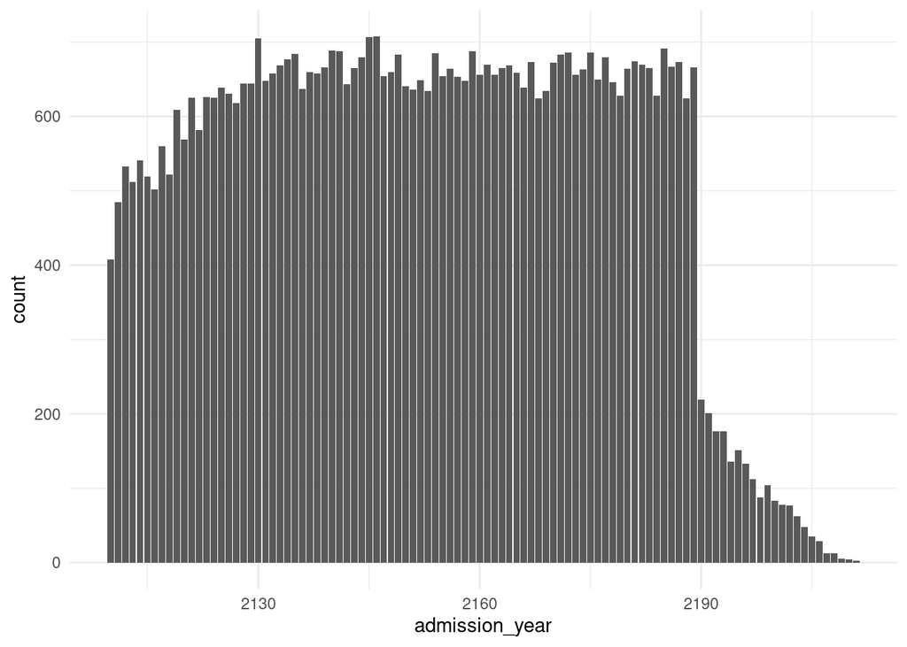

```r
admissions_tble$admittime %>%
  year() %>%
  as_tibble() %>%
  rename(admission_year = value) %>%
  ggplot() +
  geom_bar(mapping = aes(x = admission_year)) +
  theme_minimal()
```

The distribution of the admission month are shown below as the bar chart.

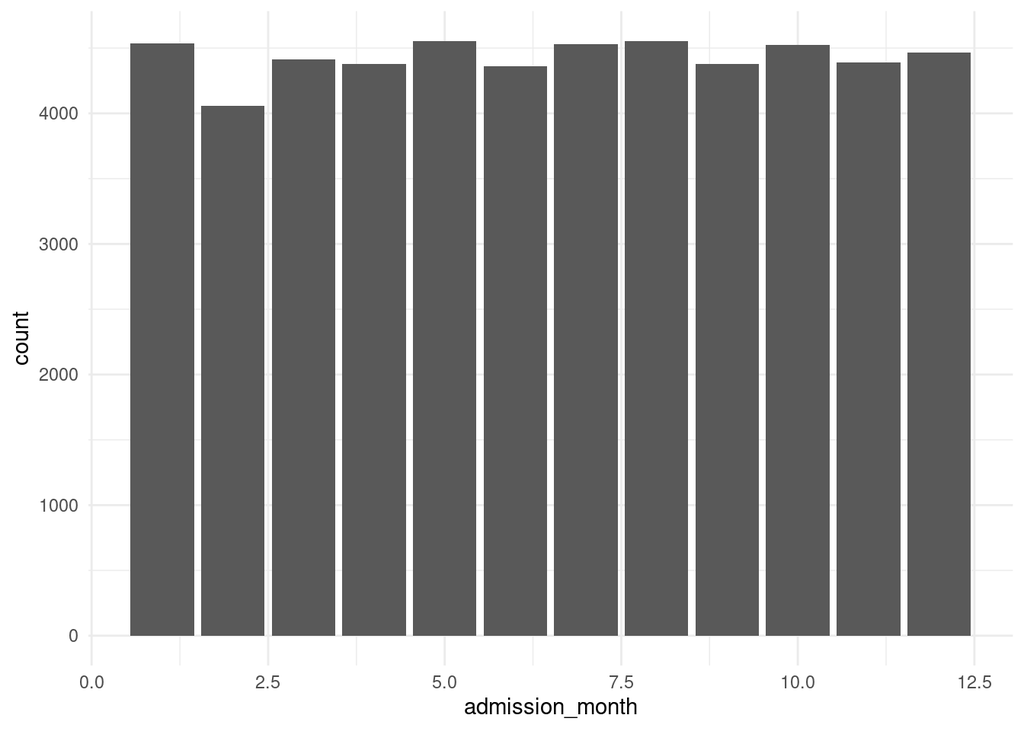

```r
admissions_tble$admittime %>%
  month() %>%
  as_tibble() %>%
  rename(admission_month = value) %>%
  ggplot() +
  geom_bar(mapping = aes(x = admission_month)) +
  theme_minimal()
```

The distribution of the admission month day are shown below as the bar chart.

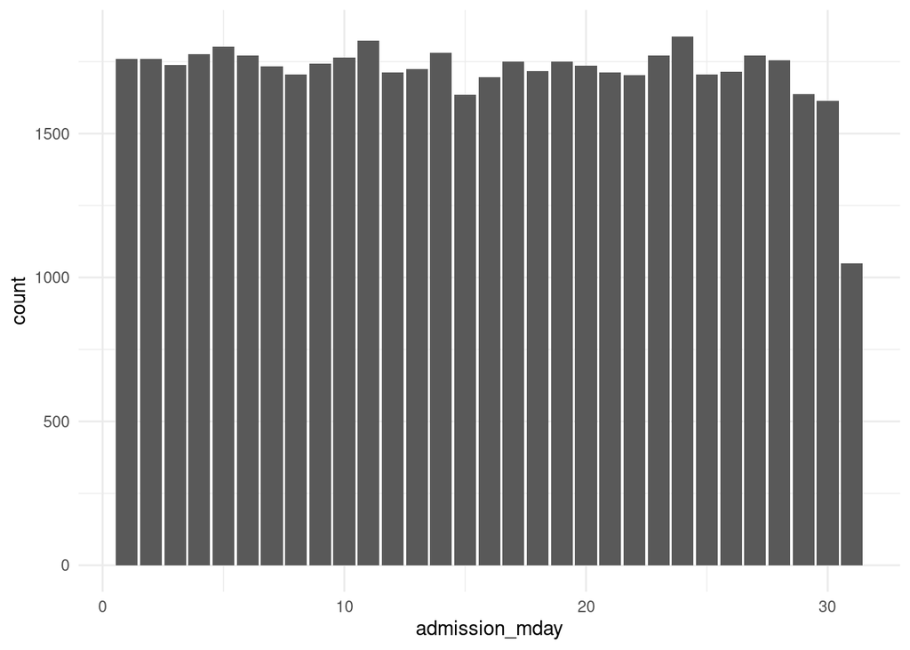

```r
admissions_tble$admittime %>%
  mday() %>%
  as_tibble() %>%
  rename(admission_mday = value) %>%
  ggplot() +
  geom_bar(mapping = aes(x = admission_mday)) +
  theme_minimal()
```

The distribution of the admission week day are shown below as the bar chart.

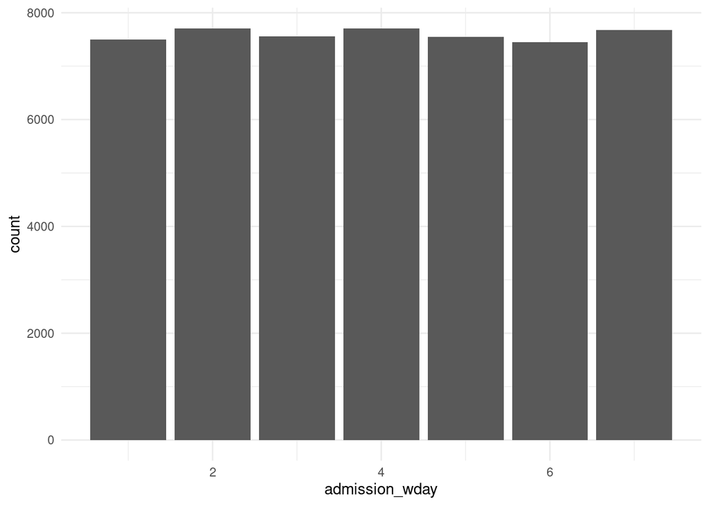

```r
admissions_tble$admittime %>%
  wday() %>%
  as_tibble() %>%
  rename(admission_wday = value) %>%
  ggplot() +
  geom_bar(mapping = aes(x = admission_wday)) +
  theme_minimal()
```

The distribution of the admission hour are shown below as the bar chart. In the bar chart, we notice that the patients mostly were admitted to the hospital at night; however, there was a unusual hour - 7 in the morning - when was the time patients got admitted a lot more than the hour before and after that.

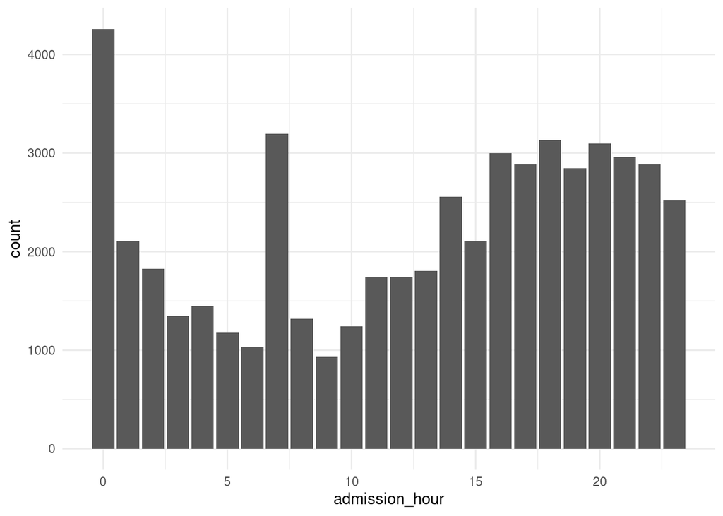

```r
admissions_tble$admittime %>%
  hour() %>%
  as_tibble() %>%
  rename(admission_hour = value) %>%
  ggplot() +
  geom_bar(mapping = aes(x = admission_hour)) +
  theme_minimal()
```

## Q4. `patients` data

Patient information is available in `patients.csv.gz`. See https://mimic.mit.edu/docs/iv/modules/core/patients/ for details of each field in this file. The first 10 lines are

```r
system(
  str_c(
    "zcat < ",
    shQuote(str_c(mimic_path, "/core/patients.csv.gz")),
    " | head"
    ),
  intern = TRUE
)
```

```
##  [1] "subject_id,gender,anchor_age,anchor_year,anchor_year_group,dod"
##  [2] "10000048,F,23,2126,2008 - 2010,"
##  [3] "10002723,F,0,2128,2017 - 2019,"
##  [4] "10003939,M,0,2184,2008 - 2010,"
##  [5] "10004222,M,0,2161,2014 - 2016,"
##  [6] "10005325,F,0,2154,2011 - 2013,"
##  [7] "10007338,F,0,2153,2017 - 2019,"
##  [8] "10008101,M,0,2142,2008 - 2010,"
##  [9] "10009872,F,0,2168,2014 - 2016,"
## [10] "10011333,F,0,2132,2014 - 2016,"
```

1. Import `patients.csv.gz` (https://mimic.mit.edu/docs/iv/modules/core/patients/) as a tibble `patients_tble` and only keep the patients who have a match in `icustays_tble` (according to `subject_id`).  
   **Solution:**

```r
patients_tble <- read_csv((str_c(mimic_path, "/core/patients.csv.gz")))
patients_tble <-
  patients_tble %>%
  semi_join(icustays_tble, by = "subject_id")
patients_tble %>%
  head()
```

```
## # A tibble: 6 × 6
##   subject_id gender anchor_age anchor_year anchor_year_group dod
##        <dbl> <chr>       <dbl>       <dbl> <chr>             <date>
## 1   10018928 F              31        2125 2008 - 2010       NA
## 2   10076543 F              78        2187 2008 - 2010       NA
## 3   10098428 F              85        2119 2008 - 2010       NA
## 4   10127185 M              60        2141 2008 - 2010       NA
## 5   10148710 M              67        2137 2008 - 2010       NA
## 6   10156486 F              75        2124 2017 - 2019       NA
```

2. Summarize variables `gender` and `anchor_age`, and explain any patterns you see.  
   **Solution:**  
   The distribution of `gender` is shown below. We can see that there are higher numbers of male patients than the numbers of female patients.

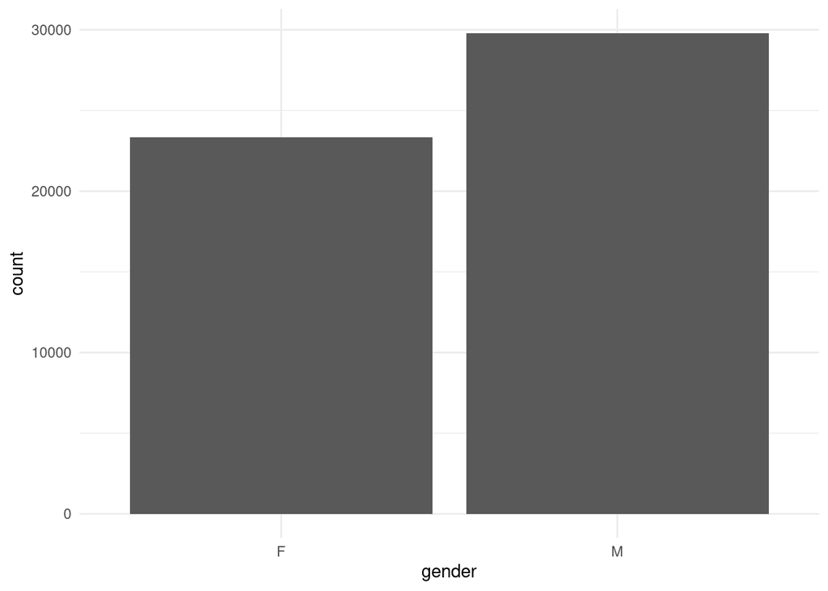

```r
patients_tble$gender %>%
  as_tibble() %>%
  rename(gender = value) %>%
  ggplot() +
  geom_bar(mapping = aes(x = gender)) +
  theme_minimal()
```

The distribution of `anchor_age` is shown below. We can see that there are a lot of 91-year-old patients, which could probably resulted from the data recorded the patients to be 91 years old for those whose ages were 91 and older. We also get the median age of these patients to be 65 years.

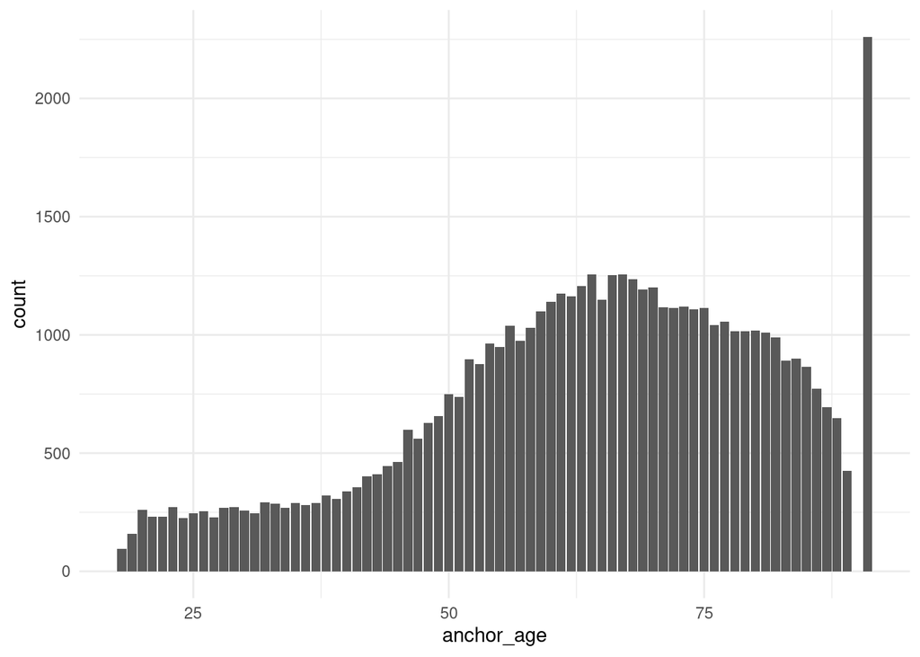

```r
patients_tble$anchor_age %>%
  as_tibble() %>%
  rename(anchor_age = value) %>%
  ggplot() +
  geom_bar(mapping = aes(x = anchor_age)) +
  theme_minimal()
```

```r
patients_tble$anchor_age %>%
  median()
```

```
## [1] 65
```

## Q5. Lab results

`labevents.csv.gz` (https://mimic.mit.edu/docs/iv/modules/hosp/labevents/) contains all laboratory measurements for patients. The first 10 lines are

```r
system(
  str_c(
    "zcat < ",
    shQuote(str_c(mimic_path, "/hosp/labevents.csv.gz")),
    " | head"
    ),
  intern = TRUE
)
```

```
##  [1] "labevent_id,subject_id,hadm_id,specimen_id,itemid,charttime,storetime,value,valuenum,valueuom,ref_range_lower,ref_range_upper,flag,priority,comments"
##  [2] "670,10000048,,6448755,51484,2126-11-22 19:20:00,2126-11-22 20:07:00,150,150,mg/dL,,,,STAT,"
##  [3] "673,10000048,,6448755,51491,2126-11-22 19:20:00,2126-11-22 20:07:00,6.5,6.5,units,5,8,,STAT,"
##  [4] "675,10000048,,6448755,51498,2126-11-22 19:20:00,2126-11-22 20:07:00,1.029,1.029, ,1.001,1.035,,STAT,"
##  [5] "683,10000048,,82729055,50861,2126-11-22 20:45:00,2126-11-23 00:55:00,39,39,IU/L,0,40,,STAT,"
##  [6] "684,10000048,,82729055,50862,2126-11-22 20:45:00,2126-11-23 00:55:00,4.7,4.7,g/dL,3.4,4.8,,STAT,"
##  [7] "685,10000048,,82729055,50863,2126-11-22 20:45:00,2126-11-23 00:55:00,45,45,IU/L,39,117,,STAT,"
##  [8] "686,10000048,,82729055,50868,2126-11-22 20:45:00,2126-11-22 21:32:00,13,13,mEq/L,8,20,,STAT,"
##  [9] "687,10000048,,82729055,50878,2126-11-22 20:45:00,2126-11-23 00:55:00,28,28,IU/L,0,40,,STAT,"
## [10] "688,10000048,,82729055,50882,2126-11-22 20:45:00,2126-11-22 21:32:00,26,26,mEq/L,22,32,,STAT,"
```

`d_labitems.csv.gz` is the dictionary of lab measurements.

```r
system(
  str_c(
    "zcat < ",
    shQuote(str_c(mimic_path, "/hosp/d_labitems.csv.gz")),
    " | head"
    ),
  intern = TRUE
)
```

```
##  [1] "itemid,label,fluid,category,loinc_code"
##  [2] "51905, ,Other Body Fluid,Chemistry,"
##  [3] "51532,11-Deoxycorticosterone,Blood,Chemistry,"
##  [4] "51957,17-Hydroxycorticosteroids,Urine,Chemistry,"
##  [5] "51958,\"17-Ketosteroids, Urine\",Urine,Chemistry,"
##  [6] "52068,24 Hr,Blood,Hematology,"
##  [7] "51066,24 hr Calcium,Urine,Chemistry,"
##  [8] "51067,24 hr Creatinine,Urine,Chemistry,"
##  [9] "51068,24 hr Protein,Urine,Chemistry,"
## [10] "50853,25-OH Vitamin D,Blood,Chemistry,"
```

1. Find how many rows are in `labevents_filtered_itemid.csv.gz`.  
   **Solution:** There are 30,198,826 rows in `labevents_filtered_itemid.csv.gz`. (There are 122,103,667 rows in `labevents.csv.gz`, for the original data set. The code is not shown because it takes too long to run.)

```r
labevents_tble <-
  read_csv((str_c(mimic_path, "/hosp/labevents_filtered_itemid.csv.gz")),
           col_select = c(subject_id,itemid,charttime,valuenum),
           col_types = cols_only(subject_id = col_double(),
                                 itemid = col_double(),
                                 charttime = col_datetime(),
                                 valuenum = col_double()),
           lazy = TRUE)
labevents_tble %>%
  nrow()
```

```
## [1] 30198826
```

2. We are interested in the lab measurements of creatinine (50912), potassium (50971), sodium (50983), chloride (50902), bicarbonate (50882), hematocrit (51221), white blood cell count (51301), glucose (50931), magnesium (50960), and calcium (50893). Retrieve a subset of `labevents_filtered_itemid.csv.gz` only containing these items for the patients in `icustays_tble` as a tibble `labevents_tble`.

   Hint: `labevents.csv.gz` is a data file too big to be read in by the `read_csv` function in its default setting. Utilize the `col_select` and `lazy` options in the `read_csv` function to reduce the memory burden.

**Solution:**

```r
labevents_tble <-
  read_csv((str_c(mimic_path, "/hosp/labevents_filtered_itemid.csv.gz")),
           col_select = c(subject_id,itemid,charttime,valuenum),
           col_types = cols_only(subject_id = col_double(),
                                 itemid = col_double(),
                                 charttime = col_datetime(),
                                 valuenum = col_double()),
           lazy = TRUE) %>%
  semi_join(icustays_tble, by = "subject_id") %>%
  filter(itemid == 50912 | 50971 | 50983 | 50902 | 50882 |
           51221 | 51301 | 50931 | 50960 | 50893)
labevents_tble %>%
  head()
```

```
## # A tibble: 6 × 4
##   subject_id itemid charttime           valuenum
##        <dbl>  <dbl> <dttm>                 <dbl>
## 1   10003700  50882 2162-11-15 17:00:00     27
## 2   10003700  50902 2162-11-15 17:00:00    103
## 3   10003700  50912 2162-11-15 17:00:00      1
## 4   10003700  50931 2162-11-15 17:00:00     93
## 5   10003700  50971 2162-11-15 17:00:00      4.1
## 6   10003700  50983 2162-11-15 17:00:00    141
```

3. Further restrict `labevents_tble` to the first lab measurement during the ICU stay.  
   **Solution:**

```r
labevents_tble <-
  left_join(labevents_tble, icustays_tble, by = c("subject_id")) %>%
  select(1:4, intime) %>%
  group_by(subject_id) %>%
  filter(charttime >= intime) %>%
  filter(charttime == min(charttime)) %>%
  ungroup()
labevents_tble %>%
  head()
```

```
## # A tibble: 6 × 5
##   subject_id itemid charttime           valuenum intime
##        <dbl>  <dbl> <dttm>                 <dbl> <dttm>
## 1   10003700  50882 2165-05-13 18:00:00     27   2165-04-24 05:43:00
## 2   10003700  50902 2165-05-13 18:00:00    102   2165-04-24 05:43:00
## 3   10003700  50912 2165-05-13 18:00:00      0.7 2165-04-24 05:43:00
## 4   10003700  50971 2165-05-13 18:00:00      4.5 2165-04-24 05:43:00
## 5   10003700  50983 2165-05-13 18:00:00    141   2165-04-24 05:43:00
## 6   10003700  51221 2165-05-13 18:00:00     41.8 2165-04-24 05:43:00
```

4. Summarize the lab measurements by appropriate numeric and graphics.  
   **Solution:**  
   The bar plot of the lab measurements and the corresponding mean of value cast of each measurements.

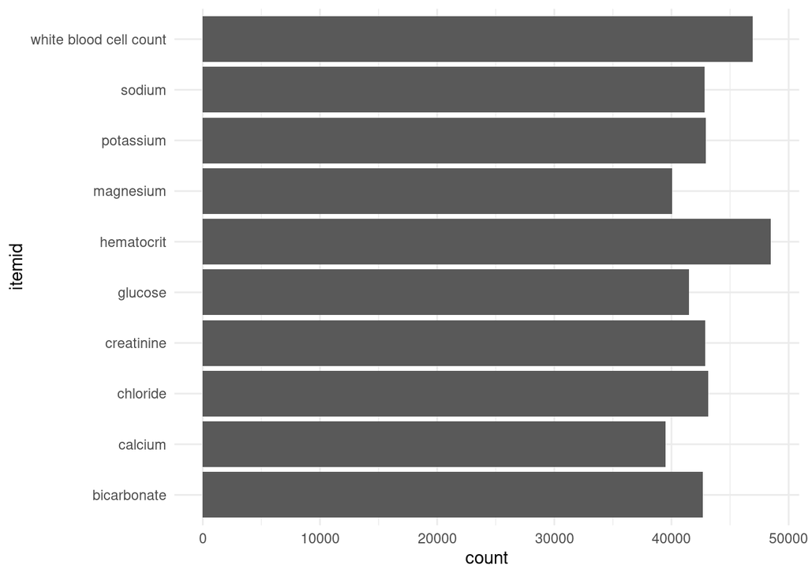

```r
labevents_tble <-
labevents_tble %>%
  mutate(itemid = recode(itemid, "50912" = "creatinine",
                         "50971" = "potassium",
                         "50983" = "sodium",
                         "50902" = "chloride",
                         "50882" = "bicarbonate",
                         "51221" = "hematocrit",
                         "51301" = "white blood cell count",
                         "50931" = "glucose",
                         "50960" = "magnesium",
                         "50893" = "calcium"))
labevents_tble%>%
  ggplot() +
  geom_bar(mapping = aes(y = itemid)) +
  theme_minimal()
```

```r
labevents_tble %>%
  group_by(itemid) %>%
  summarise(mean_valuenum = mean(valuenum, na.rm = TRUE))
```

```
## # A tibble: 10 × 2
##    itemid                 mean_valuenum
##    <chr>                          <dbl>
##  1 bicarbonate                    23.0
##  2 calcium                         8.37
##  3 chloride                      104.
##  4 creatinine                      1.36
##  5 glucose                       145.
##  6 hematocrit                     32.7
##  7 magnesium                       1.94
##  8 potassium                       4.16
##  9 sodium                        138.
## 10 white blood cell count         12.1
```

The histograms of each lab measurements are shown below. We can notice that some outliers exist in some variables: `creatinine`, `white blood cell count`, `calcium`, `magnesium`, and `glucose`, and make distributions of these variables severely right skewed. We may want to examine the data further, and decide whether to exclude these outliers or to do transformation to better evaluate our data.

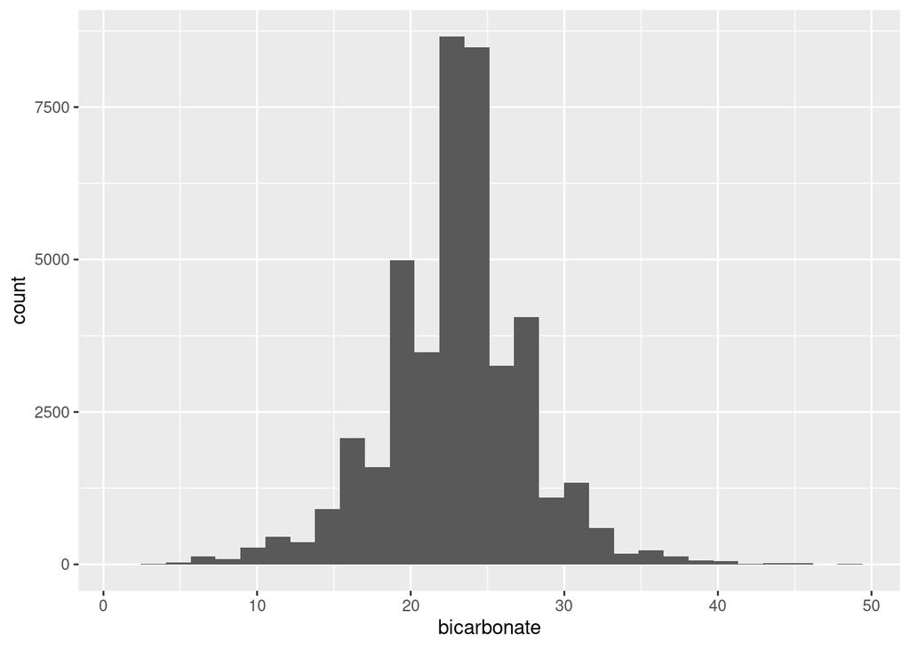

```r
labevents_tble_wide <-
  labevents_tble %>%
  pivot_wider(names_from = itemid, values_from = valuenum, values_fn = mean)
labevents_tble_wide %>%
  ggplot(mapping = aes(x = bicarbonate)) +
  geom_histogram()
```

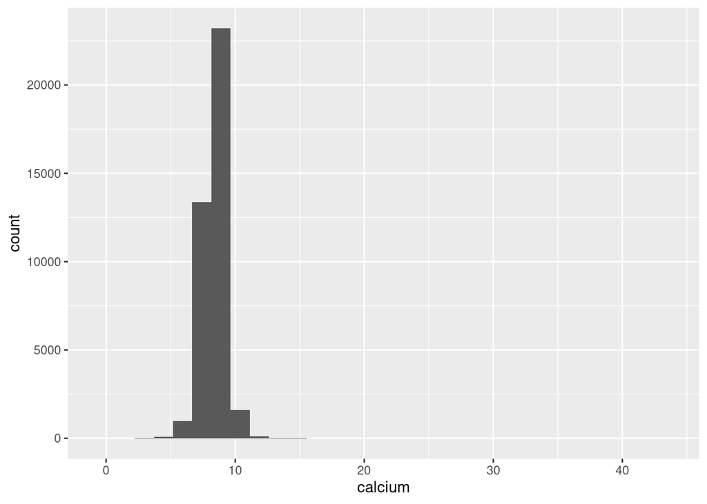

```r
labevents_tble_wide %>%
  ggplot(mapping = aes(x = calcium)) +
  geom_histogram()
```

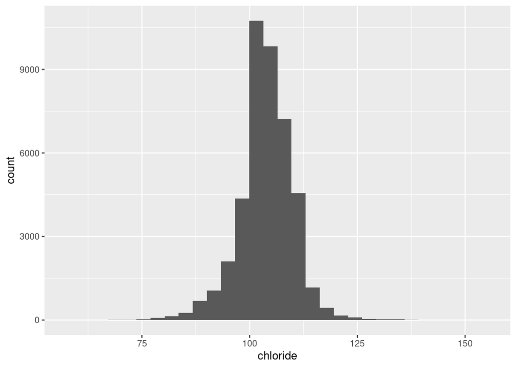

```r
labevents_tble_wide %>%
  ggplot(mapping = aes(x = chloride)) +
  geom_histogram()
```

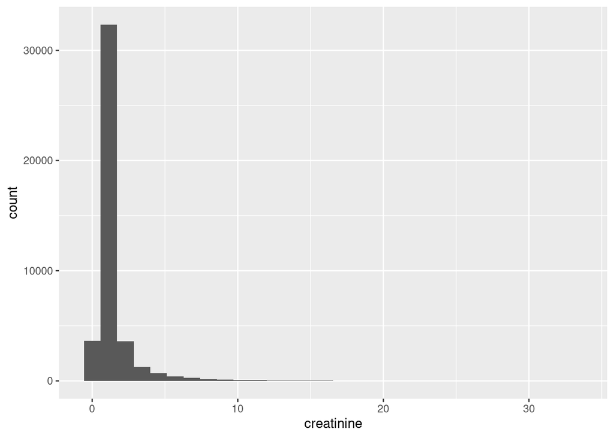

```r
labevents_tble_wide %>%
  ggplot(mapping = aes(x = creatinine)) +
  geom_histogram()
```

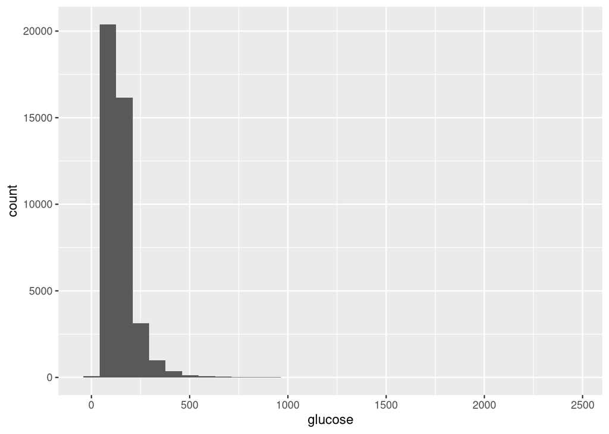

```r
labevents_tble_wide %>%
  ggplot(mapping = aes(x = glucose)) +
  geom_histogram()
```

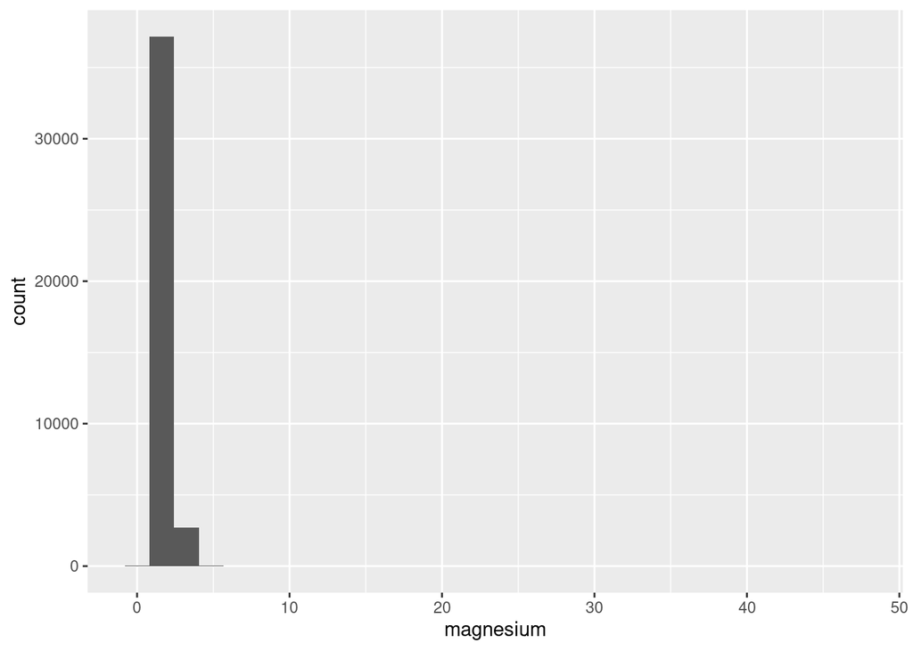

```r
labevents_tble_wide %>%
  ggplot(mapping = aes(x = magnesium)) +
  geom_histogram()
```

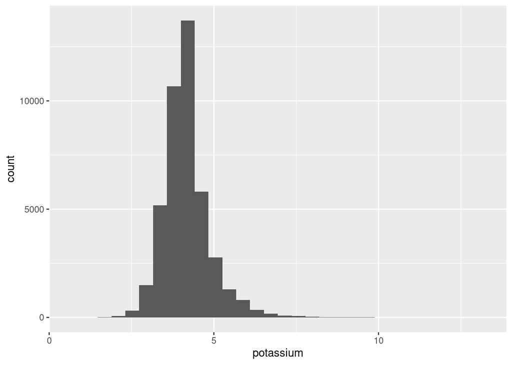

```r
labevents_tble_wide %>%
  ggplot(mapping = aes(x = potassium)) +
  geom_histogram()
```

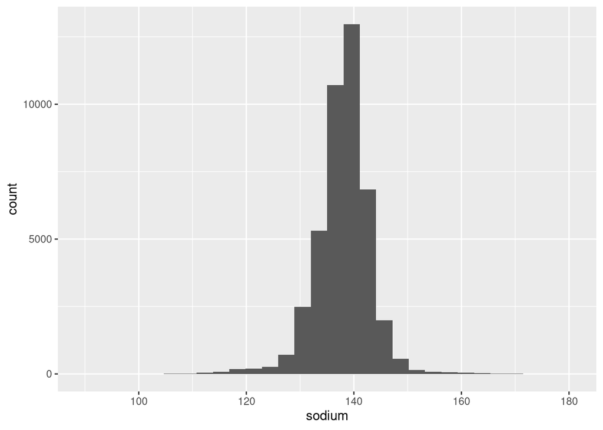

```r
labevents_tble_wide %>%
  ggplot(mapping = aes(x = sodium)) +
  geom_histogram()
```

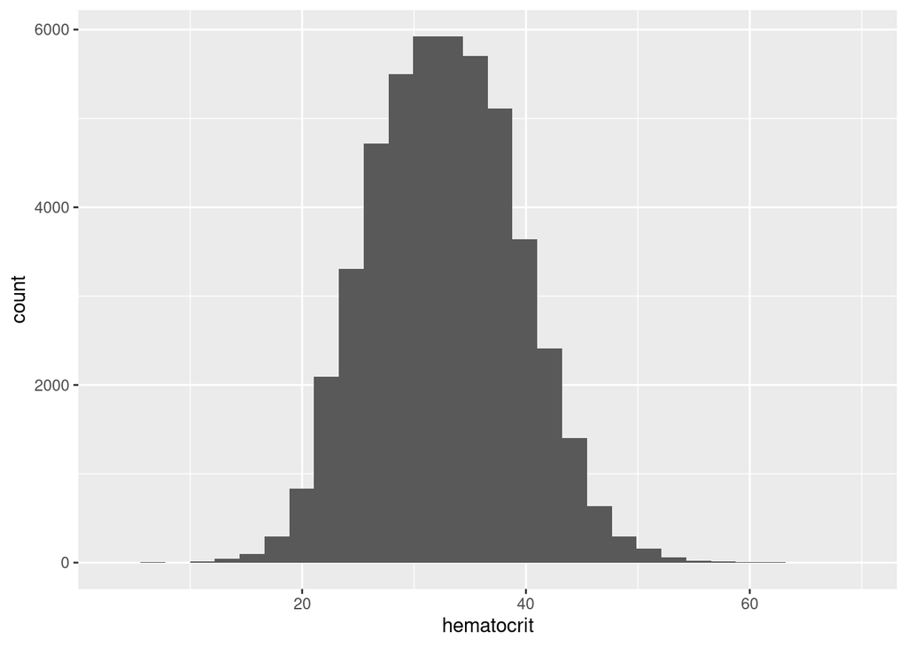

```r
labevents_tble_wide %>%
  ggplot(mapping = aes(x = hematocrit)) +
  geom_histogram()
```

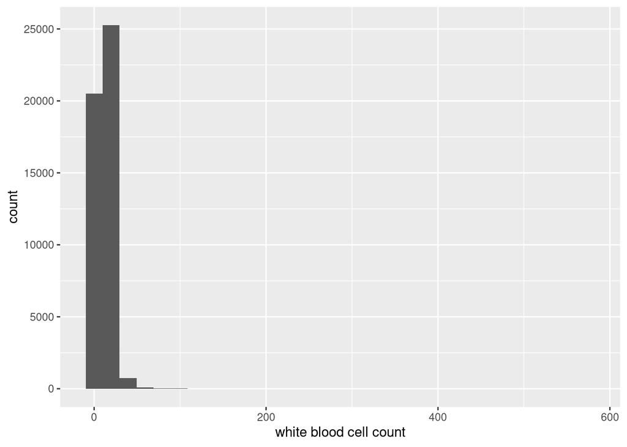

```r
labevents_tble_wide %>%
  ggplot(mapping = aes(x = `white blood cell count`)) +
  geom_histogram()
```

```r
labevents_tble_wide %>%
  select(-(subject_id:intime)) %>%
  summary()
```

```
##   bicarbonate       chloride       creatinine       potassium
##  Min.   : 2.00   Min.   : 58.0   Min.   : 0.000   Min.   : 0.800
##  1st Qu.:20.00   1st Qu.:100.0   1st Qu.: 0.700   1st Qu.: 3.700
##  Median :23.00   Median :104.0   Median : 0.900   Median : 4.100
##  Mean   :22.96   Mean   :103.8   Mean   : 1.355   Mean   : 4.158
##  3rd Qu.:26.00   3rd Qu.:108.0   3rd Qu.: 1.300   3rd Qu.: 4.500
##  Max.   :49.00   Max.   :153.0   Max.   :33.100   Max.   :13.000
##  NA's   :9927    NA's   :9465    NA's   :9710     NA's   :9675
##      sodium        hematocrit    white blood cell count    calcium
##  Min.   : 92.0   Min.   : 4.30   Min.   :  0.00         Min.   : 0.00
##  1st Qu.:136.0   1st Qu.:28.00   1st Qu.:  7.60         1st Qu.: 7.90
##  Median :139.0   Median :32.60   Median : 10.60         Median : 8.40
##  Mean   :138.4   Mean   :32.74   Mean   : 12.13         Mean   : 8.37
##  3rd Qu.:141.0   3rd Qu.:37.30   3rd Qu.: 14.60         3rd Qu.: 8.90
##  Max.   :180.0   Max.   :68.60   Max.   :572.50         Max.   :43.00
##  NA's   :9744    NA's   :4315    NA's   :5850           NA's   :13084
##    magnesium         glucose
##  Min.   : 0.000   Min.   :   7.0
##  1st Qu.: 1.700   1st Qu.: 103.0
##  Median : 1.900   Median : 126.0
##  Mean   : 1.938   Mean   : 145.3
##  3rd Qu.: 2.100   3rd Qu.: 162.0
##  Max.   :47.000   Max.   :2440.0
##  NA's   :12543    NA's   :11104
```

## Q6. Vitals from charted events

`chartevents.csv.gz` (https://mimic.mit.edu/docs/iv/modules/icu/chartevents/) contains all the charted data available for a patient. During their ICU stay, the primary repository of a patient’s information is their electronic chart. The `itemid` variable indicates a single measurement type in the database. The `value` variable is the value measured for `itemid`. The first 10 lines of `chartevents.csv.gz` are

```r
system(
  str_c(
    "zcat < ",
    shQuote(str_c(mimic_path, "/icu/chartevents.csv.gz")),
    " | head"),
  intern = TRUE
)
```

```
##  [1] "subject_id,hadm_id,stay_id,charttime,storetime,itemid,value,valuenum,valueuom,warning"
##  [2] "10003700,28623837,30600691,2165-04-24 05:10:00,2165-04-24 05:11:00,228236,0,0,,0"
##  [3] "10003700,28623837,30600691,2165-04-24 05:12:00,2165-04-24 05:14:00,225067,0,0,,0"
##  [4] "10003700,28623837,30600691,2165-04-24 05:12:00,2165-04-24 05:14:00,225070,1,1,,0"
##  [5] "10003700,28623837,30600691,2165-04-24 05:12:00,2165-04-24 05:14:00,225076,1,1,,0"
##  [6] "10003700,28623837,30600691,2165-04-24 05:12:00,2165-04-24 05:14:00,225078,1,1,,0"
##  [7] "10003700,28623837,30600691,2165-04-24 05:12:00,2165-04-24 05:14:00,225086,1,1,,0"
##  [8] "10003700,28623837,30600691,2165-04-24 05:12:00,2165-04-24 05:14:00,225091,1,1,,0"
##  [9] "10003700,28623837,30600691,2165-04-24 05:12:00,2165-04-24 05:14:00,225103,1,1,,0"
## [10] "10003700,28623837,30600691,2165-04-24 05:12:00,2165-04-24 05:14:00,225106,1,1,,0"
```

`d_items.csv.gz` (https://mimic.mit.edu/docs/iv/modules/icu/d_items/) is the dictionary for the `itemid` in `chartevents.csv.gz`.

```r
system(
  str_c(
    "zcat < ",
    shQuote(str_c(mimic_path, "/icu/d_items.csv.gz")),
    " | head"),
  intern = TRUE
)
```

```
##  [1] "itemid,label,abbreviation,linksto,category,unitname,param_type,lownormalvalue,highnormalvalue"
##  [2] "220003,ICU Admission date,ICU Admission date,datetimeevents,ADT,,Date and time,,"
##  [3] "220045,Heart Rate,HR,chartevents,Routine Vital Signs,bpm,Numeric,,"
##  [4] "220046,Heart rate Alarm - High,HR Alarm - High,chartevents,Alarms,bpm,Numeric,,"
##  [5] "220047,Heart Rate Alarm - Low,HR Alarm - Low,chartevents,Alarms,bpm,Numeric,,"
##  [6] "220048,Heart Rhythm,Heart Rhythm,chartevents,Routine Vital Signs,,Text,,"
##  [7] "220050,Arterial Blood Pressure systolic,ABPs,chartevents,Routine Vital Signs,mmHg,Numeric,90,140"
##  [8] "220051,Arterial Blood Pressure diastolic,ABPd,chartevents,Routine Vital Signs,mmHg,Numeric,60,90"
##  [9] "220052,Arterial Blood Pressure mean,ABPm,chartevents,Routine Vital Signs,mmHg,Numeric,,"
## [10] "220056,Arterial Blood Pressure Alarm - Low,ABP Alarm - Low,chartevents,Alarms,mmHg,Numeric,,"
```

1. We are interested in the vitals for ICU patients: heart rate (220045), mean non-invasive blood pressure (220181), systolic non-invasive blood pressure (220179), body temperature in Fahrenheit (223761), and respiratory rate (220210). Retrieve a subset of `chartevents_filtered_itemid.csv.gz` only containing these items for the patients in `icustays_tble` as a tibble `chartevents_tble`. **Solution:**

```r
chartevents_tble <-
  read_csv((str_c(mimic_path, "/icu/chartevents_filtered_itemid.csv.gz")),
           col_select = c(subject_id, hadm_id, stay_id,
                          itemid, charttime, valuenum),
           col_types = cols_only(subject_id = col_double(),
                                 hadm_id = col_double(),
                                 stay_id = col_double(),
                                 itemid = col_double(),
                                 charttime = col_datetime(),
                                 valuenum = col_double()),
           lazy = TRUE) %>%
  semi_join(icustays_tble, by = c("subject_id","hadm_id","stay_id")) %>%
  filter(itemid == 220045 | 220181 | 220179 | 223761 | 220210)
chartevents_tble %>%
  head()
```

```
## # A tibble: 6 × 6
##   subject_id  hadm_id  stay_id itemid charttime           valuenum
##        <dbl>    <dbl>    <dbl>  <dbl> <dttm>                 <dbl>
## 1   10003700 28623837 30600691 220179 2165-04-24 05:28:00    152
## 2   10003700 28623837 30600691 220181 2165-04-24 05:28:00    110
## 3   10003700 28623837 30600691 220045 2165-04-24 05:30:00     65
## 4   10003700 28623837 30600691 220210 2165-04-24 05:30:00     14
## 5   10003700 28623837 30600691 223761 2165-04-24 05:38:00     97.6
## 6   10003700 28623837 30600691 220045 2165-04-24 06:00:00     56
```

2. Further restrict `chartevents_tble` to the first vital measurement during the ICU stay.  
   **Solution:**

```r
chartevents_tble <-
  left_join(chartevents_tble, icustays_tble,
            by = c("subject_id","hadm_id","stay_id")) %>%
  select(1:6, intime) %>%
  group_by(subject_id) %>%
  filter(charttime >= intime) %>%
  filter(charttime == min(charttime)) %>%
  ungroup()
chartevents_tble %>%
  print(width = Inf)
```

```
## # A tibble: 116,153 × 7
##    subject_id  hadm_id  stay_id itemid charttime           valuenum
##         <dbl>    <dbl>    <dbl>  <dbl> <dttm>                 <dbl>
##  1   10003700 28623837 30600691 220045 2165-04-24 06:00:00       56
##  2   10003700 28623837 30600691 220179 2165-04-24 06:00:00      126
##  3   10003700 28623837 30600691 220181 2165-04-24 06:00:00       88
##  4   10003700 28623837 30600691 220210 2165-04-24 06:00:00       14
##  5   10004235 24181354 34100191 220045 2196-02-24 17:16:00      144
##  6   10004235 24181354 34100191 220210 2196-02-24 17:16:00       25
##  7   10004720 22081550 35009126 220045 2186-11-12 20:05:00       78
##  8   10004720 22081550 35009126 220179 2186-11-12 20:05:00      154
##  9   10004720 22081550 35009126 220181 2186-11-12 20:05:00      106
## 10   10004720 22081550 35009126 220210 2186-11-12 20:05:00       10
##    intime
##    <dttm>
##  1 2165-04-24 05:43:00
##  2 2165-04-24 05:43:00
##  3 2165-04-24 05:43:00
##  4 2165-04-24 05:43:00
##  5 2196-02-24 17:07:00
##  6 2196-02-24 17:07:00
##  7 2186-11-12 19:55:00
##  8 2186-11-12 19:55:00
##  9 2186-11-12 19:55:00
## 10 2186-11-12 19:55:00
## # … with 116,143 more rows
```

3. Summarize these vital measurements by appropriate numerics and graphics.  
   **Solution:**  
   The bar plot of the vital measurements and the corresponding mean of value cast of each measurements.

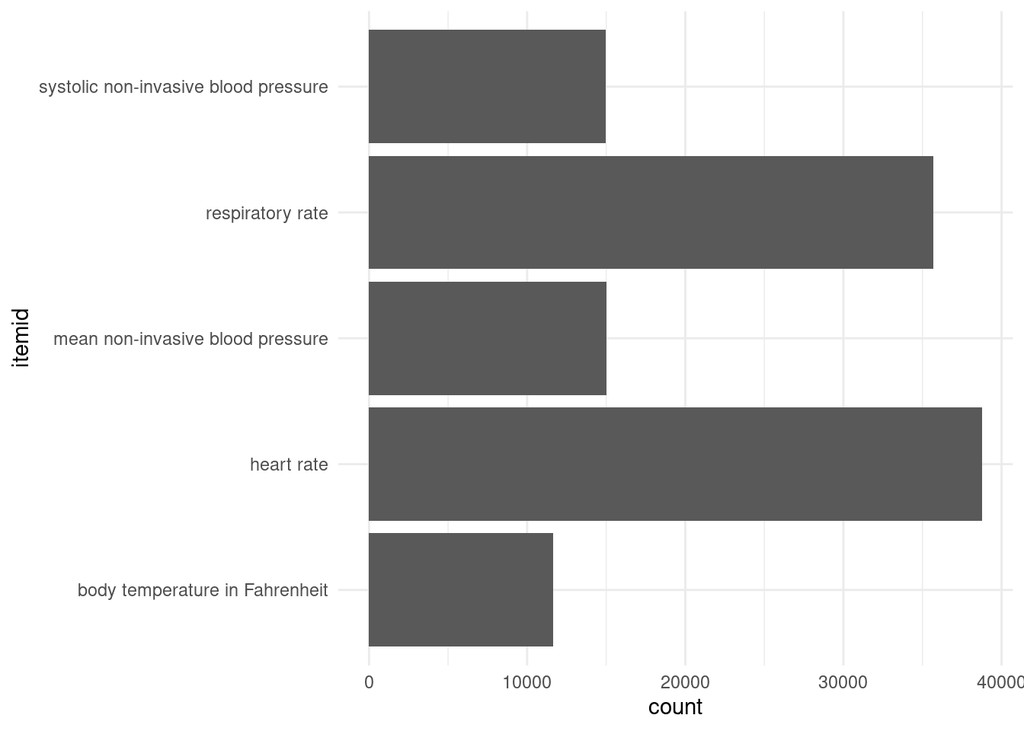

```r
chartevents_tble <-
  chartevents_tble %>%
  mutate(itemid = recode(itemid, "220045" = "heart rate",
                         "220181" = "mean non-invasive blood pressure",
                         "220179" = "systolic non-invasive blood pressure",
                         "223761" = "body temperature in Fahrenheit",
                         "220210" = "respiratory rate"))
chartevents_tble %>%
  ggplot() +
  geom_bar(mapping = aes(y = itemid)) +
  theme_minimal()
```

```r
chartevents_tble %>%
  group_by(itemid) %>%
  summarise(mean_valuenum = mean(valuenum, na.rm = TRUE))
```

```
## # A tibble: 5 × 2
##   itemid                               mean_valuenum
##   <chr>                                        <dbl>
## 1 body temperature in Fahrenheit                98.1
## 2 heart rate                                    87.2
## 3 mean non-invasive blood pressure              85.2
## 4 respiratory rate                              18.7
## 5 systolic non-invasive blood pressure         127.
```

The histograms of each vital measurements are shown below. We can notice that some outliers exist in every variables: `heart rate`, `systolic non-invasive blood pressure`, `mean non-invasive blood pressure`, `respiratory rate`, and `body temperature in Fahrenheit`, and make distributions of these variables severely either right or left skewed. We may want to examine the data further, and decide whether to exclude these outliers or to do transformation to better evaluate our data.

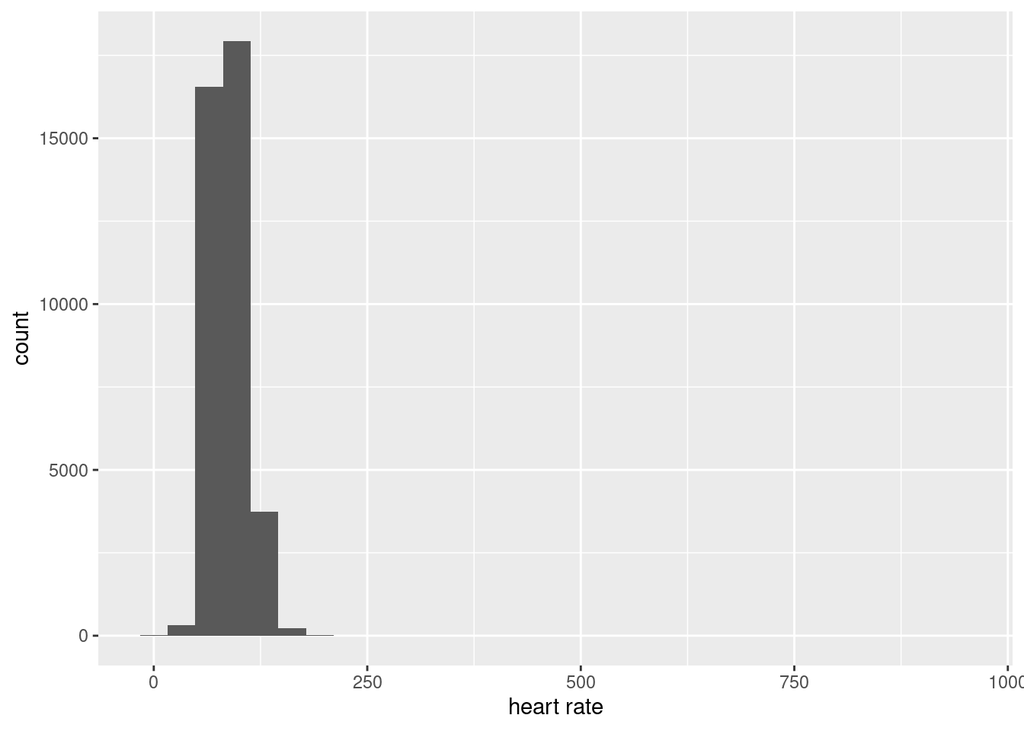

```r
chartevents_tble_wide <-
  chartevents_tble %>%
  pivot_wider(names_from = itemid, values_from = valuenum, values_fn = mean)
chartevents_tble_wide %>%
  ggplot(mapping = aes(x = `heart rate`)) +
  geom_histogram()
```

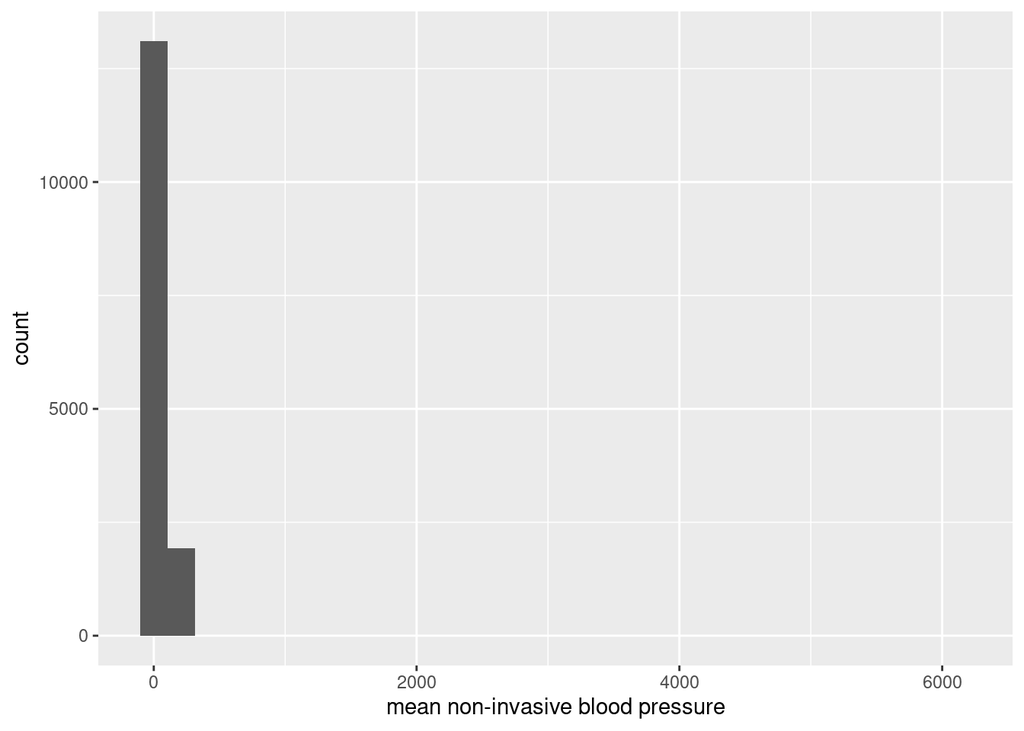

```r
chartevents_tble_wide %>%
  ggplot(mapping = aes(x = `mean non-invasive blood pressure`)) +
  geom_histogram()
```

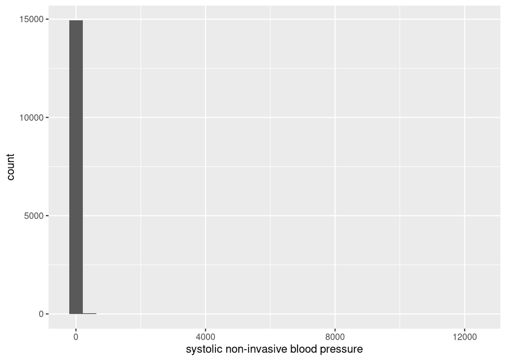

```r
chartevents_tble_wide %>%
  ggplot(mapping = aes(x = `systolic non-invasive blood pressure`)) +
  geom_histogram()
```

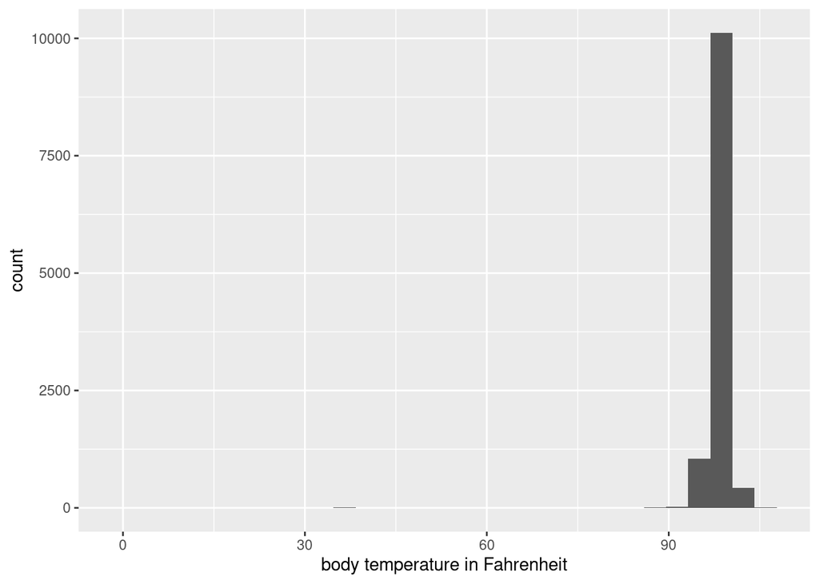

```r
chartevents_tble_wide %>%
  ggplot(mapping = aes(x = `body temperature in Fahrenheit`)) +
  geom_histogram()
```

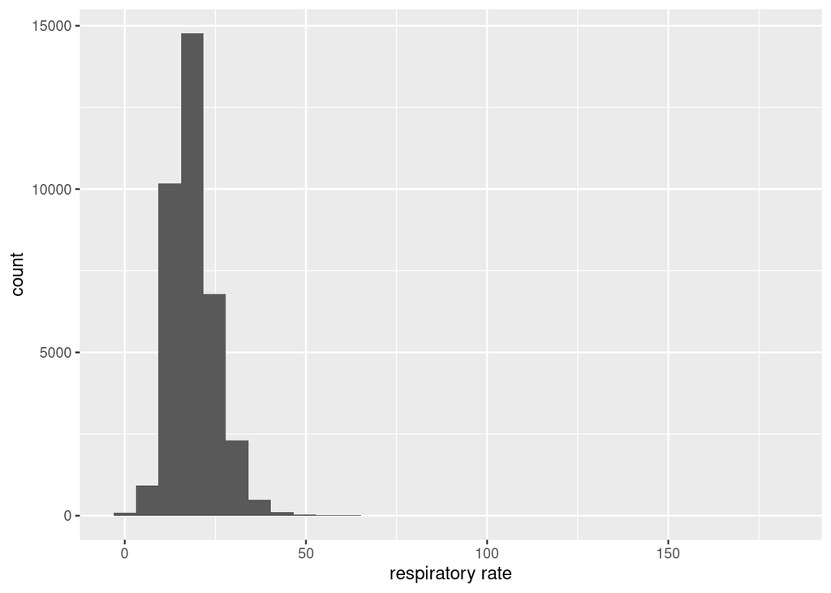

```r
chartevents_tble_wide %>%
  ggplot(mapping = aes(x = `respiratory rate`)) +
  geom_histogram()
```

```r
chartevents_tble_wide %>%
  select(-(subject_id:intime)) %>%
  summary()
```

```
##    heart rate     systolic non-invasive blood pressure
##  Min.   :  0.00   Min.   :    0.0
##  1st Qu.: 74.00   1st Qu.:  109.0
##  Median : 85.00   Median :  125.0
##  Mean   : 87.24   Mean   :  127.2
##  3rd Qu.: 99.00   3rd Qu.:  142.0
##  Max.   :941.00   Max.   :12262.0
##  NA's   :14358    NA's   :38157
##  mean non-invasive blood pressure respiratory rate
##  Min.   :   0.00                  Min.   :  0.00
##  1st Qu.:  72.00                  1st Qu.: 15.00
##  Median :  83.00                  Median : 18.00
##  Mean   :  85.23                  Mean   : 18.74
##  3rd Qu.:  96.00                  3rd Qu.: 22.00
##  Max.   :6116.00                  Max.   :180.00
##  NA's   :38098                    NA's   :17425
##  body temperature in Fahrenheit
##  Min.   :  0.00
##  1st Qu.: 97.60
##  Median : 98.10
##  Mean   : 98.07
##  3rd Qu.: 98.70
##  Max.   :106.00
##  NA's   :41489
```

## Q7. Putting things together

Let us create a tibble `mimic_icu_cohort` for all ICU stays, where rows are

- first ICU stay of each unique adult (age at admission > 18)

and columns contain at least following variables

- all variables in `icustays.csv.gz`
- all variables in `admission.csv.gz`
- all variables in `patients.csv.gz`
- first lab measurements during ICU stay
- first vital measurements during ICU stay
- an indicator variable `thirty_day_mort` whether the patient died within 30 days of hospital admission (30 day mortality) **Solution:**

```r
labevents_tble_merge <-
  labevents_tble_wide %>%
  select(-(charttime:intime))
chartevents_tble_merge <-
  chartevents_tble_wide %>%
  select(-hadm_id, -(charttime:intime))
mimic_icu_cohort <-
  icustays_tble %>%
  left_join(admissions_tble, by = c("subject_id", "hadm_id")) %>%
  left_join(patients_tble, by = "subject_id") %>%
  left_join(labevents_tble_merge, by = "subject_id") %>%
  left_join(chartevents_tble_merge, by = c("subject_id", "stay_id")) %>%
  mutate(age_admission = year(admittime) + anchor_age - anchor_year) %>%
  filter(age_admission > 18) %>%
  mutate(thirty_day_mort = ifelse((deathtime - admittime) <= 43200,
                                  "Yes", "No")) %>%
  mutate(thirty_day_mort = replace_na(thirty_day_mort, "No")) %>%
  print(width = Inf)
```

```
## # A tibble: 53,065 × 43
##    subject_id  hadm_id  stay_id first_careunit
##         <dbl>    <dbl>    <dbl> <chr>
##  1   17867402 24528534 31793211 Trauma SICU (TSICU)
##  2   14435996 28960964 31983544 Trauma SICU (TSICU)
##  3   17609946 27385897 33183475 Trauma SICU (TSICU)
##  4   18966770 23483021 34131444 Trauma SICU (TSICU)
##  5   12776735 20817525 34547665 Neuro Stepdown
##  6   10215159 24283593 34569476 Trauma SICU (TSICU)
##  7   14489052 26516390 35056286 Trauma SICU (TSICU)
##  8   15914763 28906020 36909804 Trauma SICU (TSICU)
##  9   16256226 20013290 39289362 Neuro Stepdown
## 10   19194449 21641999 39387567 Coronary Care Unit (CCU)
##    last_careunit            intime              outtime               los
##    <chr>                    <dttm>              <dttm>              <dbl>
```

[output cut: 119 more lines]

## Q8. Exploratory data analysis (EDA)

Summarize following information using appropriate numerics or graphs.

- `thirty_day_mort` vs demographic variables (ethnicity, language, insurance, marital_status, gender, age at hospital admission)  
  **Solution:**

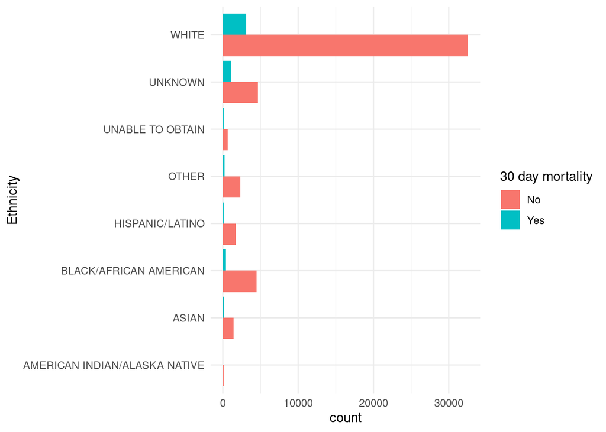

```r
mimic_icu_cohort %>%
  ggplot(mapping = aes(y = ethnicity, fill = thirty_day_mort)) +
  geom_bar(position="dodge") +
  labs(fill = "30 day mortality", y = "Ethnicity") +
  theme_minimal()
```

```r
mimic_icu_cohort %>%
  group_by(ethnicity) %>%
  summarise(n = n(),
            `Died within 30 days` = sum(thirty_day_mort == "Yes"),
            Proportion_Yes = `Died within 30 days` / n,
            `Did not die within 30 days` = sum(thirty_day_mort == "No"),
            Proportion_No = `Did not die within 30 days` / n)
```

```
## # A tibble: 8 × 6
##   ethnicity     n `Died within 30… Proportion_Yes `Did not die wi… Proportion_No
##   <chr>     <int>            <int>          <dbl>            <int>         <dbl>
## 1 AMERICAN…    94                7         0.0745               87         0.926
## 2 ASIAN      1561              161         0.103              1400         0.897
## 3 BLACK/AF…  4867              380         0.0781             4487         0.922
## 4 HISPANIC…  1821              115         0.0632             1706         0.937
## 5 OTHER      2530              211         0.0834             2319         0.917
## 6 UNABLE T…   755              119         0.158               636         0.842
## 7 UNKNOWN    5811             1135         0.195              4676         0.805
## 8 WHITE     35626             3082         0.0865            32544         0.913
```

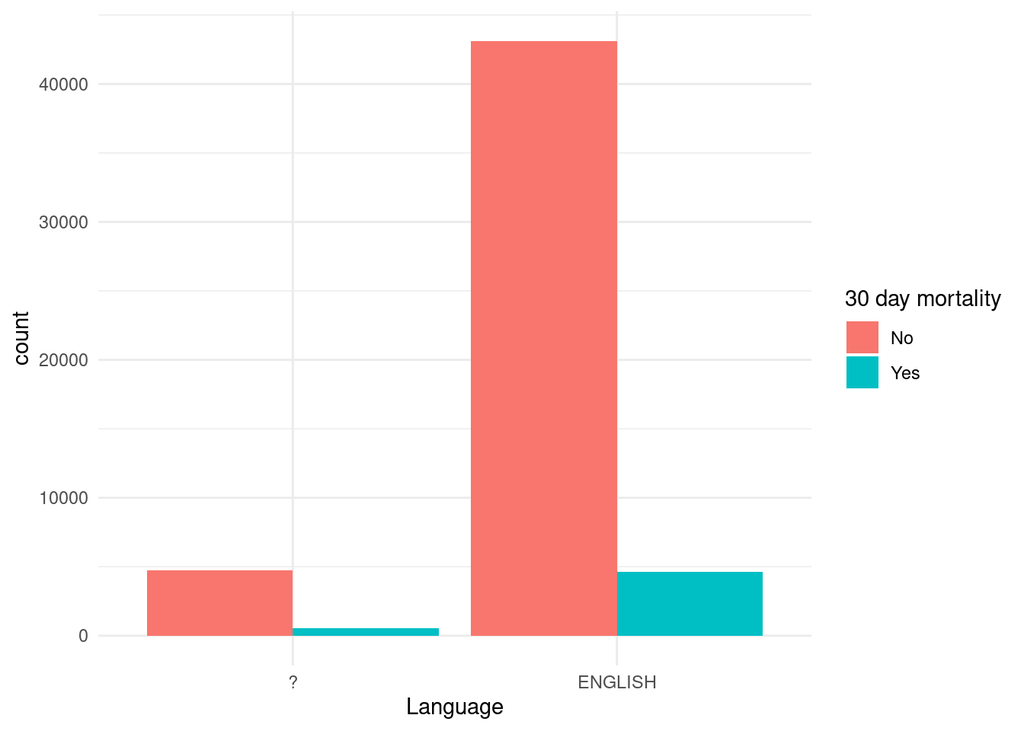

```r
mimic_icu_cohort %>%
  ggplot(mapping = aes(x = language, fill = thirty_day_mort)) +
  geom_bar(position="dodge") +
  labs(fill = "30 day mortality", x = "Language") +
  theme_minimal()
```

```r
mimic_icu_cohort %>%
  group_by(language) %>%
  summarise(n = n(),
            `Died within 30 days` = sum(thirty_day_mort == "Yes"),
            Proportion_Yes = `Died within 30 days` / n,
            `Did not die within 30 days` = sum(thirty_day_mort == "No"),
            Proportion_No = `Did not die within 30 days` / n)
```

```
## # A tibble: 2 × 6
##   language     n `Died within 30 … Proportion_Yes `Did not die wi… Proportion_No
##   <chr>    <int>             <int>          <dbl>            <int>         <dbl>
## 1 ?         5290               560         0.106              4730         0.894
## 2 ENGLISH  47775              4650         0.0973            43125         0.903
```

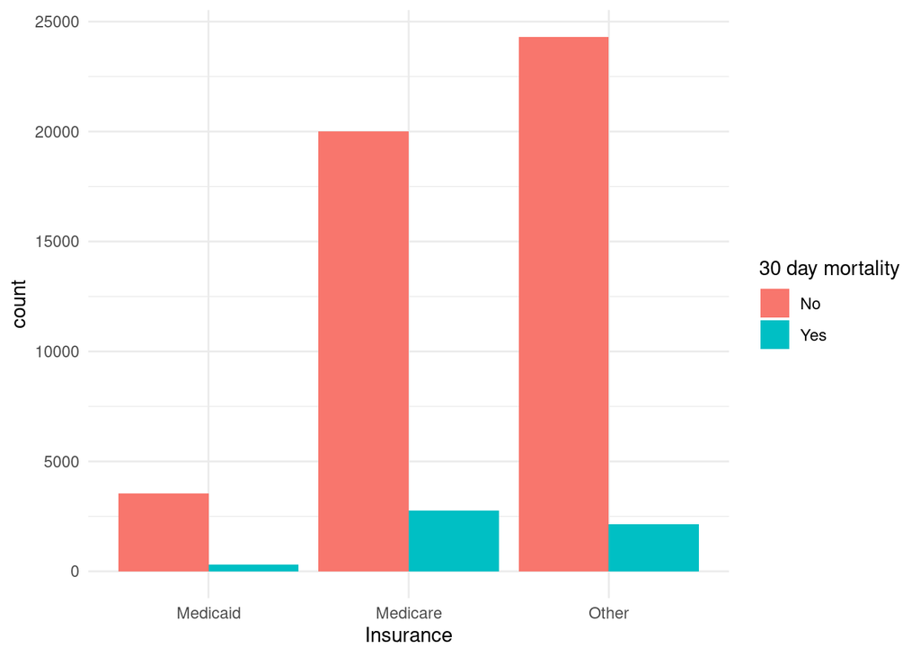

```r
mimic_icu_cohort %>%
  ggplot(mapping = aes(x = insurance, fill = thirty_day_mort)) +
  geom_bar(position="dodge") +
  labs(fill = "30 day mortality", x = "Insurance") +
  theme_minimal()
```

```r
mimic_icu_cohort %>%
  group_by(insurance) %>%
  summarise(n = n(),
            `Died within 30 days` = sum(thirty_day_mort == "Yes"),
            Proportion_Yes = `Died within 30 days` / n,
            `Did not die within 30 days` = sum(thirty_day_mort == "No"),
            Proportion_No = `Did not die within 30 days` / n)
```

```
## # A tibble: 3 × 6
##   insurance     n `Died within 30… Proportion_Yes `Did not die wi… Proportion_No
##   <chr>     <int>            <int>          <dbl>            <int>         <dbl>
## 1 Medicaid   3829              297         0.0776             3532         0.922
## 2 Medicare  22776             2766         0.121             20010         0.879
## 3 Other     26460             2147         0.0811            24313         0.919
```

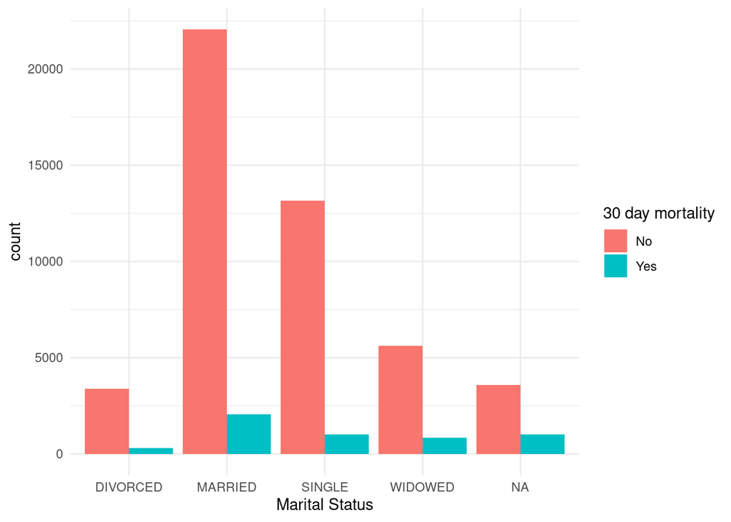

```r
mimic_icu_cohort %>%
  ggplot(mapping = aes(x = marital_status, fill = thirty_day_mort)) +
  geom_bar(position="dodge") +
  labs(fill = "30 day mortality", x = "Marital Status") +
  theme_minimal()
```

```r
mimic_icu_cohort %>%
  group_by(marital_status) %>%
  summarise(n = n(),
            `Died within 30 days` = sum(thirty_day_mort == "Yes"),
            Proportion_Yes = `Died within 30 days` / n,
            `Did not die within 30 days` = sum(thirty_day_mort == "No"),
            Proportion_No = `Did not die within 30 days` / n)
```

```
## # A tibble: 5 × 6
##   marital_status     n `Died within 30 days` Proportion_Yes `Did not die within…
##   <chr>          <int>                 <int>          <dbl>                <int>
## 1 DIVORCED        3695                   296         0.0801                 3399
## 2 MARRIED        24112                  2049         0.0850                22063
## 3 SINGLE         14171                  1001         0.0706                13170
## 4 WIDOWED         6470                   841         0.130                  5629
## 5 <NA>            4617                  1023         0.222                  3594
## # … with 1 more variable: Proportion_No <dbl>
```

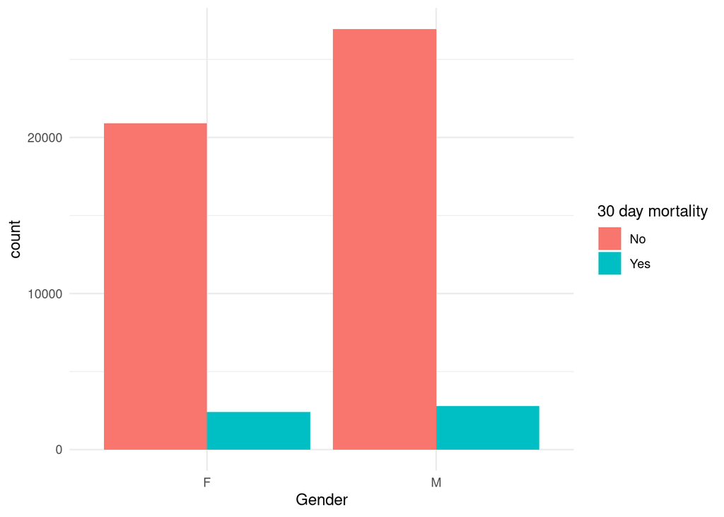

```r
mimic_icu_cohort %>%
  ggplot(mapping = aes(x = gender, fill = thirty_day_mort)) +
  geom_bar(position="dodge") +
  labs(fill = "30 day mortality", x = "Gender") +
  theme_minimal()
```

```r
mimic_icu_cohort %>%
  group_by(gender) %>%
  summarise(n = n(),
            `Died within 30 days` = sum(thirty_day_mort == "Yes"),
            Proportion_Yes = `Died within 30 days` / n,
            `Did not die within 30 days` = sum(thirty_day_mort == "No"),
            Proportion_No = `Did not die within 30 days` / n)
```

```
## # A tibble: 2 × 6
##   gender     n `Died within 30 … Proportion_Yes `Did not die with… Proportion_No
##   <chr>  <int>             <int>          <dbl>              <int>         <dbl>
## 1 F      23314              2411         0.103               20903         0.897
## 2 M      29751              2799         0.0941              26952         0.906
```

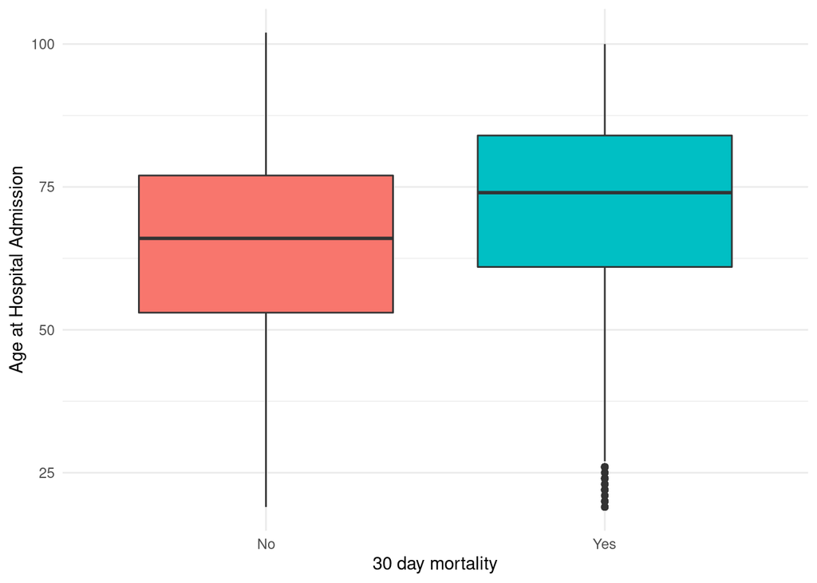

```r
mimic_icu_cohort %>%
  ggplot(mapping = aes(y = age_admission,
                       x = thirty_day_mort,
                       fill = thirty_day_mort)) +
  geom_boxplot() +
  labs(x = "30 day mortality", y = "Age at Hospital Admission") +
  theme_minimal() +
  theme(legend.position = "none")
```

```r
mimic_icu_cohort %>%
  group_by(thirty_day_mort) %>%
  summarise(n = n(),
            mean = mean(age_admission, na.rm = TRUE),
            standard_deviation = sd(age_admission, na.rm = TRUE),
            min = min(age_admission),
            Q1 = quantile(age_admission, 0.25),
            median = median(age_admission, na.rm = TRUE),
            Q3 = quantile(age_admission, 0.75),
            max = max(age_admission))
```

```
## # A tibble: 2 × 9
##   thirty_day_mort     n  mean standard_deviation   min    Q1 median    Q3   max
##   <chr>           <int> <dbl>              <dbl> <dbl> <dbl>  <dbl> <dbl> <dbl>
## 1 No              47855  63.8               17.2    19    53     66    77   102
## 2 Yes              5210  71.3               15.5    19    61     74    84   100
```

- `thirty_day_mort` vs first lab measurements  
  **Solution:**

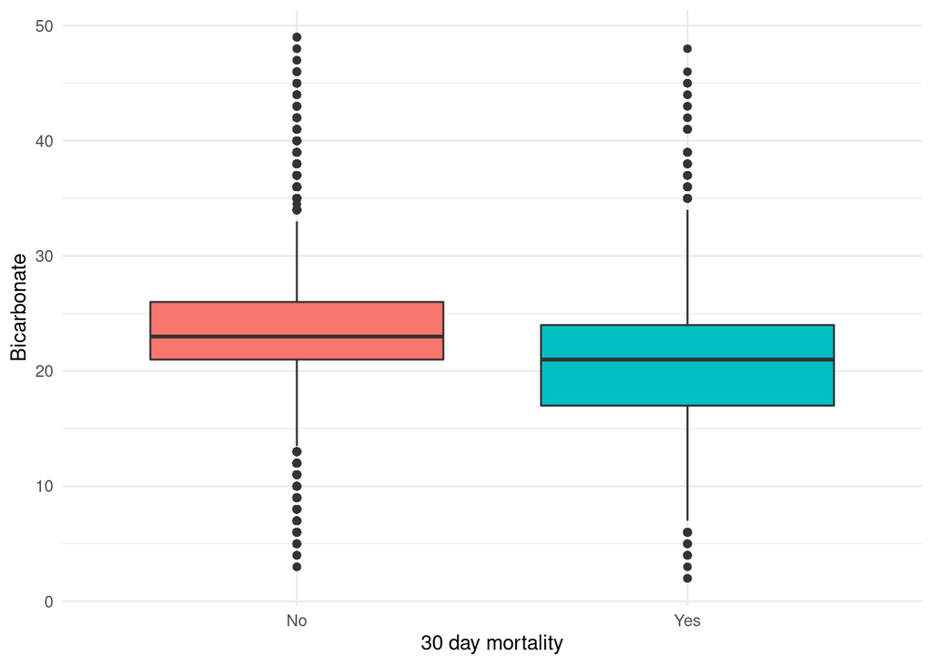

```r
mimic_icu_cohort %>%
  ggplot(mapping = aes(y = bicarbonate,
                       x = thirty_day_mort,
                       fill = thirty_day_mort)) +
  geom_boxplot() +
  labs(x = "30 day mortality", y = "Bicarbonate") +
  theme_minimal() +
  theme(legend.position = "none")
```

```r
mimic_icu_cohort %>%
  group_by(thirty_day_mort) %>%
  summarise(n = n(),
            mean = mean(bicarbonate, na.rm = TRUE),
            standard_deviation = sd(bicarbonate, na.rm = TRUE),
            min = min(bicarbonate, na.rm = TRUE),
            Q1 = quantile(bicarbonate, 0.25, na.rm = TRUE),
            median = median(bicarbonate, na.rm = TRUE),
            Q3 = quantile(bicarbonate, 0.75, na.rm = TRUE),
            max = max(bicarbonate, na.rm = TRUE))
```

```
## # A tibble: 2 × 9
##   thirty_day_mort     n  mean standard_deviation   min    Q1 median    Q3   max
##   <chr>           <int> <dbl>              <dbl> <dbl> <dbl>  <dbl> <dbl> <dbl>
## 1 No              47855  23.2               4.44     3    21     23    26    49
## 2 Yes              5210  20.9               5.88     2    17     21    24    48
```

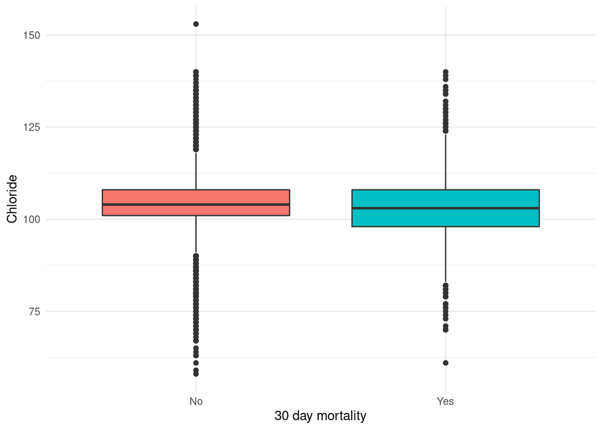

```r
mimic_icu_cohort %>%
  ggplot(mapping = aes(y = chloride,
                       x = thirty_day_mort,
                       fill = thirty_day_mort)) +
  geom_boxplot() +
  labs(x = "30 day mortality", y = "Chloride") +
  theme_minimal() +
  theme(legend.position = "none")
```

```r
mimic_icu_cohort %>%
  group_by(thirty_day_mort) %>%
  summarise(n = n(),
            mean = mean(chloride, na.rm = TRUE),
            standard_deviation = sd(chloride, na.rm = TRUE),
            min = min(chloride, na.rm = TRUE),
            Q1 = quantile(chloride, 0.25, na.rm = TRUE),
            median = median(chloride, na.rm = TRUE),
            Q3 = quantile(chloride, 0.75, na.rm = TRUE),
            max = max(chloride, na.rm = TRUE))
```

```
## # A tibble: 2 × 9
##   thirty_day_mort     n  mean standard_deviation   min    Q1 median    Q3   max
##   <chr>           <int> <dbl>              <dbl> <dbl> <dbl>  <dbl> <dbl> <dbl>
## 1 No              47855  104.               6.16    58   101    104   108   153
## 2 Yes              5210  103.               7.90    61    98    103   108   140
```

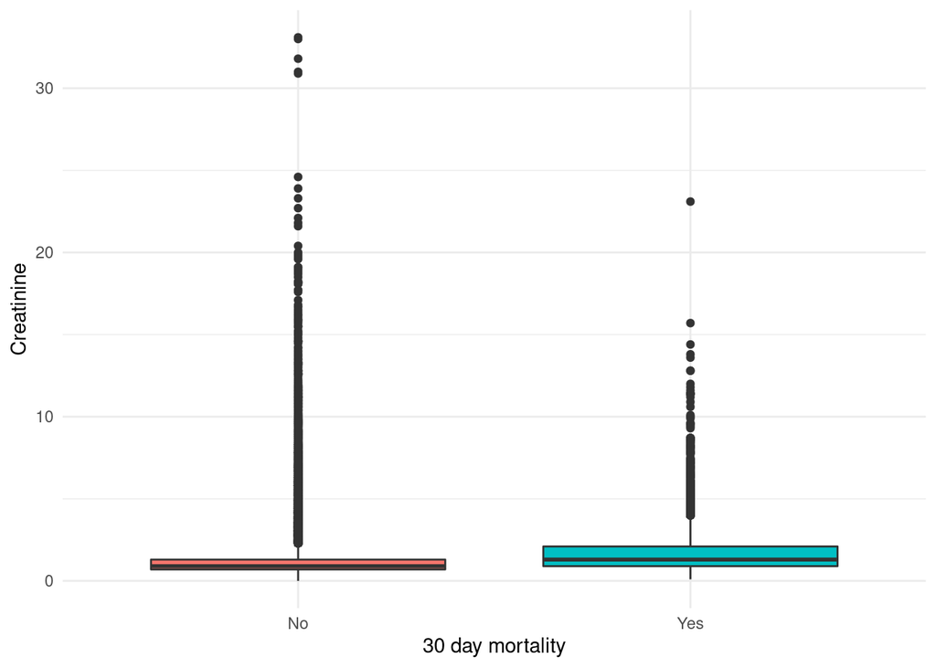

```r
mimic_icu_cohort %>%
  ggplot(mapping = aes(y = creatinine,
                       x = thirty_day_mort,
                       fill = thirty_day_mort)) +
  geom_boxplot() +
  labs(x = "30 day mortality", y = "Creatinine") +
  theme_minimal() +
  theme(legend.position = "none")
```

```r
mimic_icu_cohort %>%
  group_by(thirty_day_mort) %>%
  summarise(n = n(),
            mean = mean(creatinine, na.rm = TRUE),
            standard_deviation = sd(creatinine, na.rm = TRUE),
            min = min(creatinine, na.rm = TRUE),
            Q1 = quantile(creatinine, 0.25, na.rm = TRUE),
            median = median(creatinine, na.rm = TRUE),
            Q3 = quantile(creatinine, 0.75, na.rm = TRUE),
            max = max(creatinine, na.rm = TRUE))
```

```
## # A tibble: 2 × 9
##   thirty_day_mort     n  mean standard_deviation   min    Q1 median    Q3   max
##   <chr>           <int> <dbl>              <dbl> <dbl> <dbl>  <dbl> <dbl> <dbl>
## 1 No              47855  1.30               1.51   0     0.7    0.9   1.3  33.1
## 2 Yes              5210  1.79               1.56   0.1   0.9    1.3   2.1  23.1
```

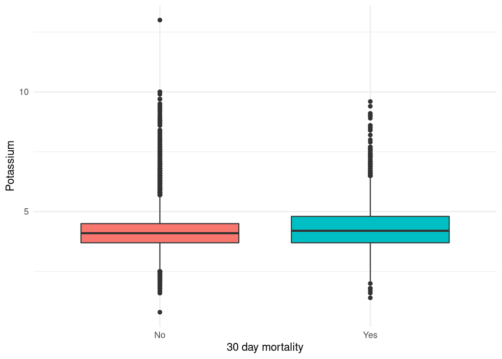

```r
mimic_icu_cohort %>%
  ggplot(mapping = aes(y = potassium,
                       x = thirty_day_mort,
                       fill = thirty_day_mort)) +
  geom_boxplot() +
  labs(x = "30 day mortality", y = "Potassium") +
  theme_minimal() +
  theme(legend.position = "none")
```

```r
mimic_icu_cohort %>%
  group_by(thirty_day_mort) %>%
  summarise(n = n(),
            mean = mean(potassium, na.rm = TRUE),
            standard_deviation = sd(potassium, na.rm = TRUE),
            min = min(potassium, na.rm = TRUE),
            Q1 = quantile(potassium, 0.25, na.rm = TRUE),
            median = median(potassium, na.rm = TRUE),
            Q3 = quantile(potassium, 0.75, na.rm = TRUE),
            max = max(potassium, na.rm = TRUE))
```

```
## # A tibble: 2 × 9
##   thirty_day_mort     n  mean standard_deviation   min    Q1 median    Q3   max
##   <chr>           <int> <dbl>              <dbl> <dbl> <dbl>  <dbl> <dbl> <dbl>
## 1 No              47855  4.14              0.697   0.8   3.7    4.1   4.5  13
## 2 Yes              5210  4.34              0.903   1.4   3.7    4.2   4.8   9.6
```

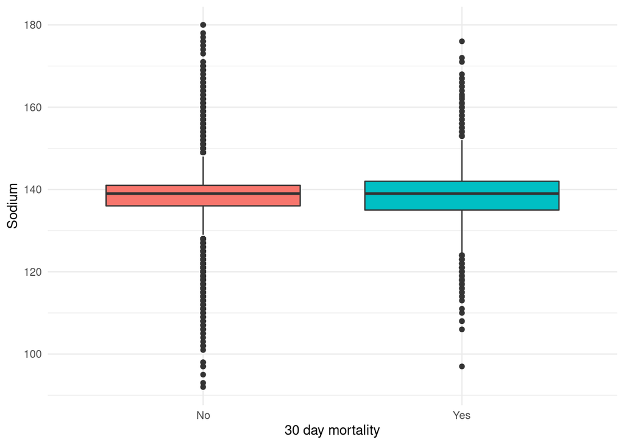

```r
mimic_icu_cohort %>%
  ggplot(mapping = aes(y = sodium,
                       x = thirty_day_mort,
                       fill = thirty_day_mort)) +
  geom_boxplot() +
  labs(x = "30 day mortality", y = "Sodium") +
  theme_minimal() +
  theme(legend.position = "none")
```

```r
mimic_icu_cohort %>%
  group_by(thirty_day_mort) %>%
  summarise(n = n(),
            mean = mean(sodium, na.rm = TRUE),
            standard_deviation = sd(sodium, na.rm = TRUE),
            min = min(sodium, na.rm = TRUE),
            Q1 = quantile(sodium, 0.25, na.rm = TRUE),
            median = median(sodium, na.rm = TRUE),
            Q3 = quantile(sodium, 0.75, na.rm = TRUE),
            max = max(sodium, na.rm = TRUE))
```

```
## # A tibble: 2 × 9
##   thirty_day_mort     n  mean standard_deviation   min    Q1 median    Q3   max
##   <chr>           <int> <dbl>              <dbl> <dbl> <dbl>  <dbl> <dbl> <dbl>
## 1 No              47855  138.               5.04    92   136    139   141   180
## 2 Yes              5210  138.               6.62    97   135    139   142   176
```

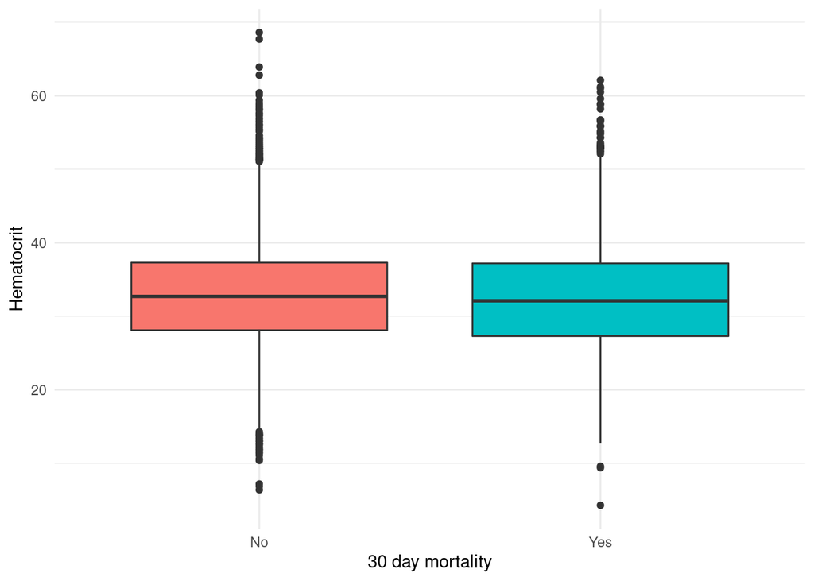

```r
mimic_icu_cohort %>%
  ggplot(mapping = aes(y = hematocrit,
                       x = thirty_day_mort,
                       fill = thirty_day_mort)) +
  geom_boxplot() +
  labs(x = "30 day mortality", y = "Hematocrit") +
  theme_minimal() +
  theme(legend.position = "none")
```

```r
mimic_icu_cohort %>%
  group_by(thirty_day_mort) %>%
  summarise(n = n(),
            mean = mean(hematocrit, na.rm = TRUE),
            standard_deviation = sd(hematocrit, na.rm = TRUE),
            min = min(hematocrit, na.rm = TRUE),
            Q1 = quantile(hematocrit, 0.25, na.rm = TRUE),
            median = median(hematocrit, na.rm = TRUE),
            Q3 = quantile(hematocrit, 0.75, na.rm = TRUE),
            max = max(hematocrit, na.rm = TRUE))
```

```
## # A tibble: 2 × 9
##   thirty_day_mort     n  mean standard_deviation   min    Q1 median    Q3   max
##   <chr>           <int> <dbl>              <dbl> <dbl> <dbl>  <dbl> <dbl> <dbl>
## 1 No              47855  32.8               6.45   6.4  28.1   32.7  37.3  68.6
## 2 Yes              5210  32.5               7.28   4.3  27.3   32.1  37.2  62.1
```

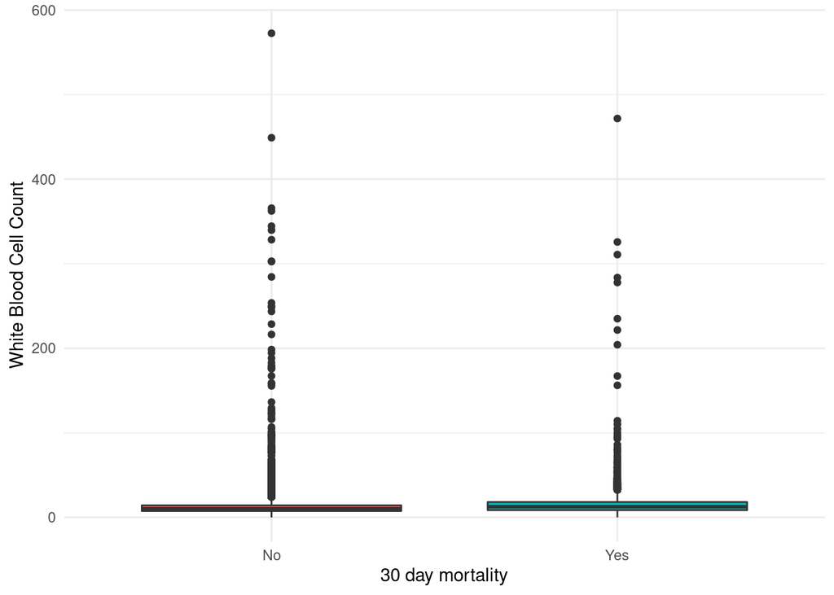

```r
mimic_icu_cohort %>%
  ggplot(mapping = aes(y =`white blood cell count`,
                       x = thirty_day_mort,
                       fill = thirty_day_mort)) +
  geom_boxplot() +
  labs(x = "30 day mortality", y = "White Blood Cell Count") +
  theme_minimal() +
  theme(legend.position = "none")
```

```r
mimic_icu_cohort %>%
  group_by(thirty_day_mort) %>%
  summarise(n = n(),
            mean = mean(`white blood cell count`, na.rm = TRUE),
            standard_deviation = sd(`white blood cell count`, na.rm = TRUE),
            min = min(`white blood cell count`, na.rm = TRUE),
            Q1 = quantile(`white blood cell count`, 0.25, na.rm = TRUE),
            median = median(`white blood cell count`, na.rm = TRUE),
            Q3 = quantile(`white blood cell count`, 0.75, na.rm = TRUE),
            max = max(`white blood cell count`, na.rm = TRUE))
```

```
## # A tibble: 2 × 9
##   thirty_day_mort     n  mean standard_deviation   min    Q1 median    Q3   max
##   <chr>           <int> <dbl>              <dbl> <dbl> <dbl>  <dbl> <dbl> <dbl>
## 1 No              47855  11.8               9.47   0     7.6   10.4  14.3  572.
## 2 Yes              5210  15.3              16.5    0.1   8.6   12.7  18.2  472.
```

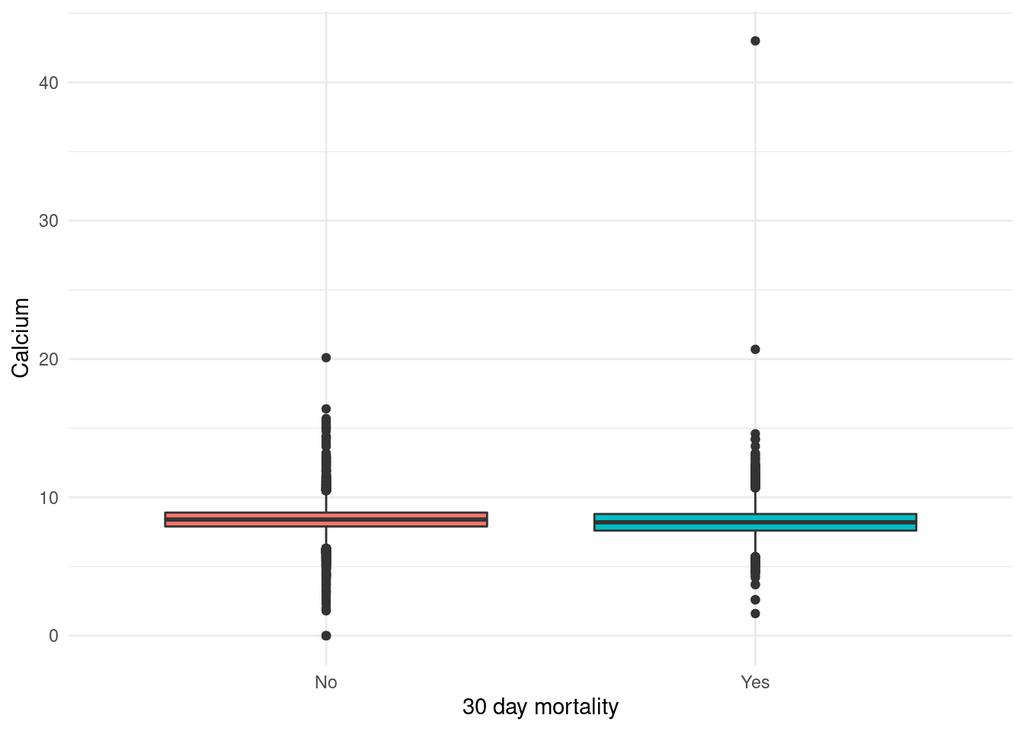

```r
mimic_icu_cohort %>%
  ggplot(mapping = aes(y = calcium,
                       x = thirty_day_mort,
                       fill = thirty_day_mort)) +
  geom_boxplot() +
  labs(x = "30 day mortality", y = "Calcium") +
  theme_minimal() +
  theme(legend.position = "none")
```

```r
mimic_icu_cohort %>%
  group_by(thirty_day_mort) %>%
  summarise(n = n(),
            mean = mean(calcium, na.rm = TRUE),
            standard_deviation = sd(calcium, na.rm = TRUE),
            min = min(calcium, na.rm = TRUE),
            Q1 = quantile(calcium, 0.25, na.rm = TRUE),
            median = median(calcium, na.rm = TRUE),
            Q3 = quantile(calcium, 0.75, na.rm = TRUE),
            max = max(calcium, na.rm = TRUE))
```

```
## # A tibble: 2 × 9
##   thirty_day_mort     n  mean standard_deviation   min    Q1 median    Q3   max
##   <chr>           <int> <dbl>              <dbl> <dbl> <dbl>  <dbl> <dbl> <dbl>
## 1 No              47855  8.39              0.843   0     7.9    8.4   8.9  20.1
## 2 Yes              5210  8.20              1.21    1.6   7.6    8.2   8.8  43
```

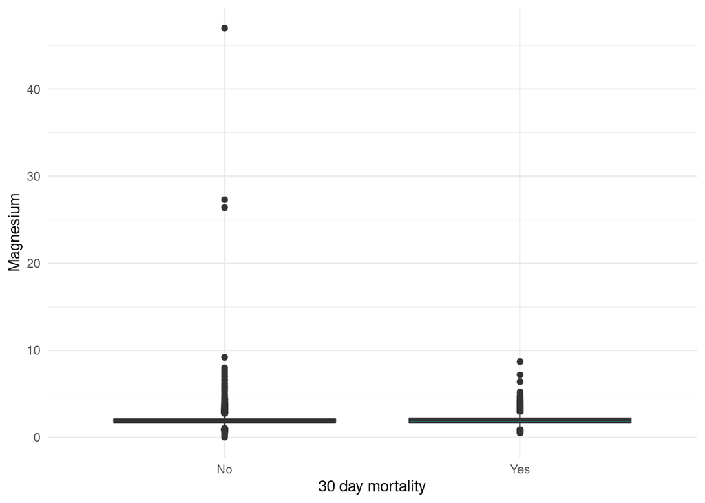

```r
mimic_icu_cohort %>%
  ggplot(mapping = aes(y = magnesium,
                       x = thirty_day_mort,
                       fill = thirty_day_mort)) +
  geom_boxplot() +
  labs(x = "30 day mortality", y = "Magnesium") +
  theme_minimal() +
  theme(legend.position = "none")
```

```r
mimic_icu_cohort %>%
  group_by(thirty_day_mort) %>%
  summarise(n = n(),
            mean = mean(magnesium, na.rm = TRUE),
            standard_deviation = sd(magnesium, na.rm = TRUE),
            min = min(magnesium, na.rm = TRUE),
            Q1 = quantile(magnesium, 0.25, na.rm = TRUE),
            median = median(magnesium, na.rm = TRUE),
            Q3 = quantile(magnesium, 0.75, na.rm = TRUE),
            max = max(magnesium, na.rm = TRUE))
```

```
## # A tibble: 2 × 9
##   thirty_day_mort     n  mean standard_deviation   min    Q1 median    Q3   max
##   <chr>           <int> <dbl>              <dbl> <dbl> <dbl>  <dbl> <dbl> <dbl>
## 1 No              47855  1.93              0.481   0     1.7    1.9   2.1  47
## 2 Yes              5210  2.03              0.460   0.5   1.7    2     2.2   8.7
```

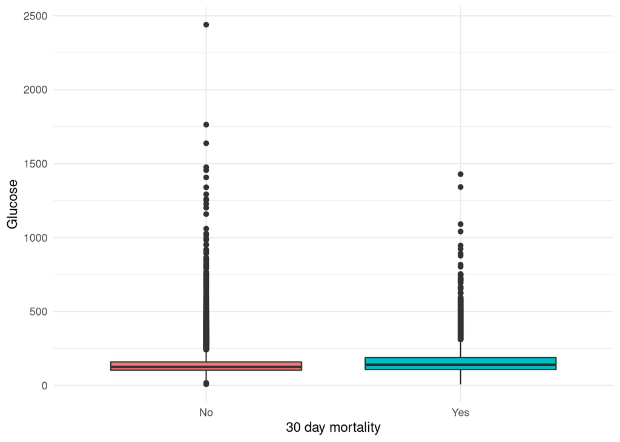

```r
mimic_icu_cohort %>%
  ggplot(mapping = aes(y = glucose,
                       x = thirty_day_mort,
                       fill = thirty_day_mort)) +
  geom_boxplot() +
  labs(x = "30 day mortality", y = "Glucose") +
  theme_minimal() +
  theme(legend.position = "none")
```

```r
mimic_icu_cohort %>%
  group_by(thirty_day_mort) %>%
  summarise(n = n(),
            mean = mean(glucose, na.rm = TRUE),
            standard_deviation = sd(glucose, na.rm = TRUE),
            min = min(glucose, na.rm = TRUE),
            Q1 = quantile(glucose, 0.25, na.rm = TRUE),
            median = median(glucose, na.rm = TRUE),
            Q3 = quantile(glucose, 0.75, na.rm = TRUE),
            max = max(glucose, na.rm = TRUE))
```

```
## # A tibble: 2 × 9
##   thirty_day_mort     n  mean standard_deviation   min    Q1 median    Q3   max
##   <chr>           <int> <dbl>              <dbl> <dbl> <dbl>  <dbl> <dbl> <dbl>
## 1 No              47855  143.               73.4     8   103    125   159  2440
## 2 Yes              5210  165.               99.3     7   108    140   189  1429
```

- `thirty_day_mort` vs first vital measurements  
  **Solution:**

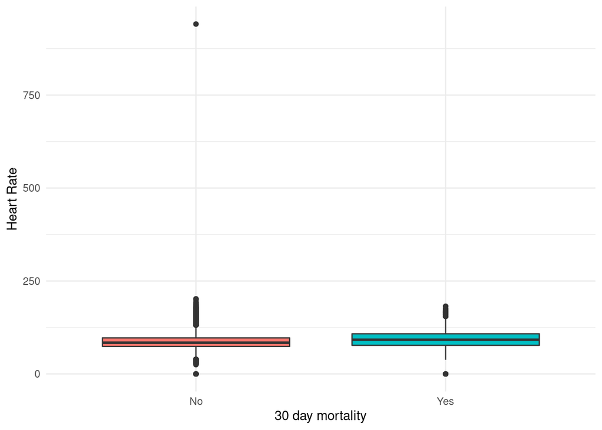

```r
mimic_icu_cohort %>%
  ggplot(mapping = aes(y = `heart rate`,
                       x = thirty_day_mort,
                       fill = thirty_day_mort)) +
  geom_boxplot() +
  labs(x = "30 day mortality", y = "Heart Rate") +
  theme_minimal() +
  theme(legend.position = "none")
```

```r
mimic_icu_cohort %>%
  group_by(thirty_day_mort) %>%
  summarise(n = n(),
            mean = mean(`heart rate`, na.rm = TRUE),
            standard_deviation = sd(`heart rate`, na.rm = TRUE),
            min = min(`heart rate`, na.rm = TRUE),
            Q1 = quantile(`heart rate`, 0.25, na.rm = TRUE),
            median = median(`heart rate`, na.rm = TRUE),
            Q3 = quantile(`heart rate`, 0.75, na.rm = TRUE),
            max = max(`heart rate`, na.rm = TRUE))
```

```
## # A tibble: 2 × 9
##   thirty_day_mort     n  mean standard_deviation   min    Q1 median    Q3   max
##   <chr>           <int> <dbl>              <dbl> <dbl> <dbl>  <dbl> <dbl> <dbl>
## 1 No              47855  86.6               19.7     0    74     84    97   941
## 2 Yes              5210  93.0               22.3     0    77     92   108   182
```

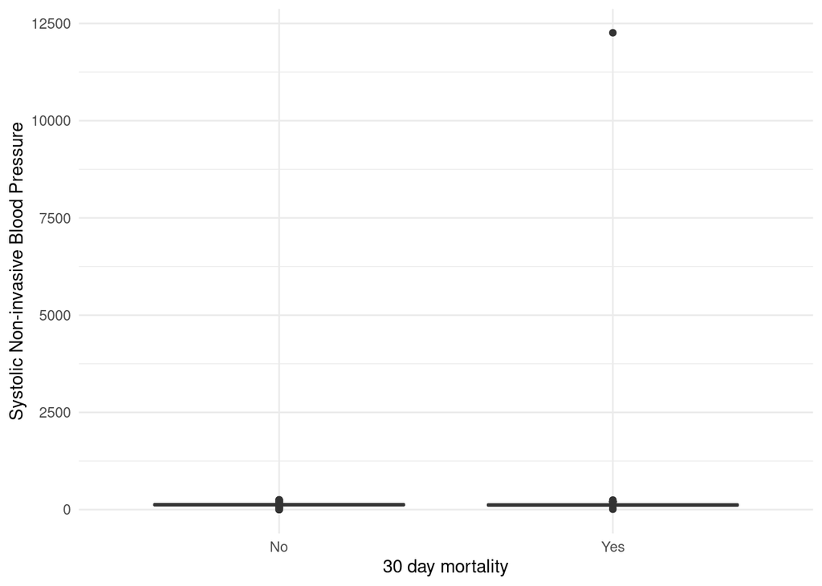

```r
mimic_icu_cohort %>%
  ggplot(mapping = aes(y = `systolic non-invasive blood pressure`,
                       x = thirty_day_mort,
                       fill = thirty_day_mort)) +
  geom_boxplot() +
  labs(x = "30 day mortality", y = "Systolic Non-invasive Blood Pressure") +
  theme_minimal() +
  theme(legend.position = "none")
```

```r
mimic_icu_cohort %>%
  group_by(thirty_day_mort) %>%
  summarise(n = n(),
            mean = mean(`systolic non-invasive blood pressure`,
                        na.rm = TRUE),
            standard_deviation = sd(`systolic non-invasive blood pressure`,
                                    na.rm = TRUE),
            min = min(`systolic non-invasive blood pressure`, na.rm = TRUE),
            Q1 = quantile(`systolic non-invasive blood pressure`,
                          0.25, na.rm = TRUE),
            median = median(`systolic non-invasive blood pressure`,
                            na.rm = TRUE),
            Q3 = quantile(`systolic non-invasive blood pressure`,
                          0.75, na.rm = TRUE),
            max = max(`systolic non-invasive blood pressure`, na.rm = TRUE))
```

```
## # A tibble: 2 × 9
##   thirty_day_mort     n  mean standard_deviation   min    Q1 median    Q3   max
##   <chr>           <int> <dbl>              <dbl> <dbl> <dbl>  <dbl> <dbl> <dbl>
## 1 No              47855  127.               24.2     0   110    126   143   253
## 2 Yes              5210  127.              289.      9   101    118   138 12262
```

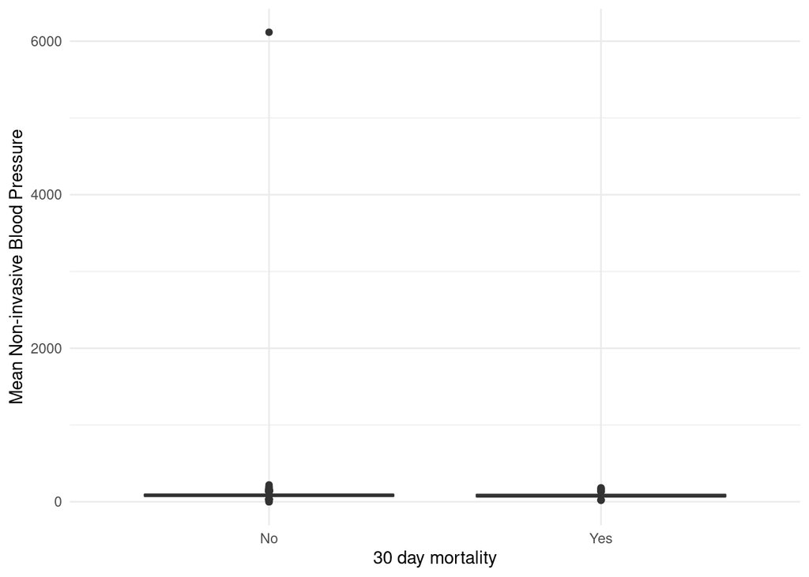

```r
mimic_icu_cohort %>%
  ggplot(mapping = aes(y = `mean non-invasive blood pressure`,
                       x = thirty_day_mort,
                       fill = thirty_day_mort)) +
  geom_boxplot() +
  labs(x = "30 day mortality", y = "Mean Non-invasive Blood Pressure") +
  theme_minimal() +
  theme(legend.position = "none")
```

```r
mimic_icu_cohort %>%
  group_by(thirty_day_mort) %>%
  summarise(n = n(),
            mean = mean(`mean non-invasive blood pressure`,
                        na.rm = TRUE),
            standard_deviation = sd(`mean non-invasive blood pressure`,
                                    na.rm = TRUE),
            min = min(`mean non-invasive blood pressure`, na.rm = TRUE),
            Q1 = quantile(`mean non-invasive blood pressure`,
                          0.25, na.rm = TRUE),
            median = median(`mean non-invasive blood pressure`,
                            na.rm = TRUE),
            Q3 = quantile(`mean non-invasive blood pressure`,
                          0.75, na.rm = TRUE),
            max = max(`mean non-invasive blood pressure`, na.rm = TRUE))
```

```
## # A tibble: 2 × 9
##   thirty_day_mort     n  mean standard_deviation   min    Q1 median    Q3   max
##   <chr>           <int> <dbl>              <dbl> <dbl> <dbl>  <dbl> <dbl> <dbl>
## 1 No              47855  85.8               55.6     0    73     84    96  6116
## 2 Yes              5210  81.4               20.6    19    67     79    94   182
```

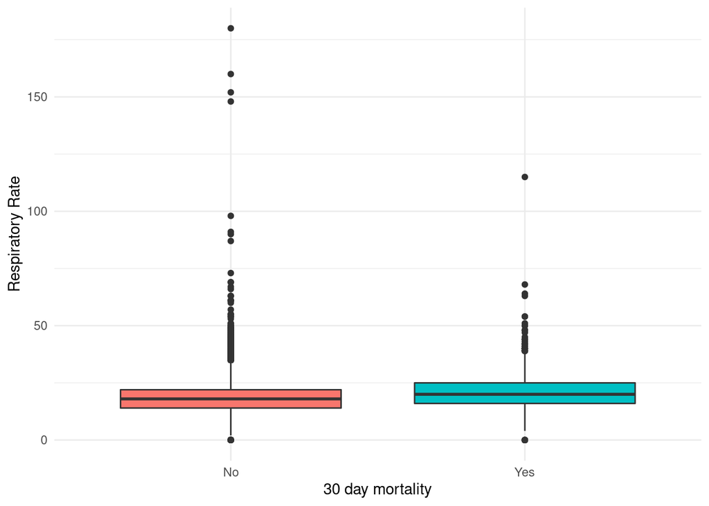

```r
mimic_icu_cohort %>%
  ggplot(mapping = aes(y = `respiratory rate`,
                       x = thirty_day_mort,
                       fill = thirty_day_mort)) +
  geom_boxplot() +
  labs(x = "30 day mortality", y = "Respiratory Rate") +
  theme_minimal() +
  theme(legend.position = "none")
```

```r
mimic_icu_cohort %>%
  group_by(thirty_day_mort) %>%
  summarise(n = n(),
            mean = mean(`respiratory rate`, na.rm = TRUE),
            standard_deviation = sd(`respiratory rate`, na.rm = TRUE),
            min = min(`respiratory rate`, na.rm = TRUE),
            Q1 = quantile(`respiratory rate`, 0.25, na.rm = TRUE),
            median = median(`respiratory rate`, na.rm = TRUE),
            Q3 = quantile(`respiratory rate`, 0.75, na.rm = TRUE),
            max = max(`respiratory rate`, na.rm = TRUE))
```

```
## # A tibble: 2 × 9
##   thirty_day_mort     n  mean standard_deviation   min    Q1 median    Q3   max
##   <chr>           <int> <dbl>              <dbl> <dbl> <dbl>  <dbl> <dbl> <dbl>
## 1 No              47855  18.5               6.21     0    14     18    22   180
## 2 Yes              5210  21.2               6.92     0    16     20    25   115
```

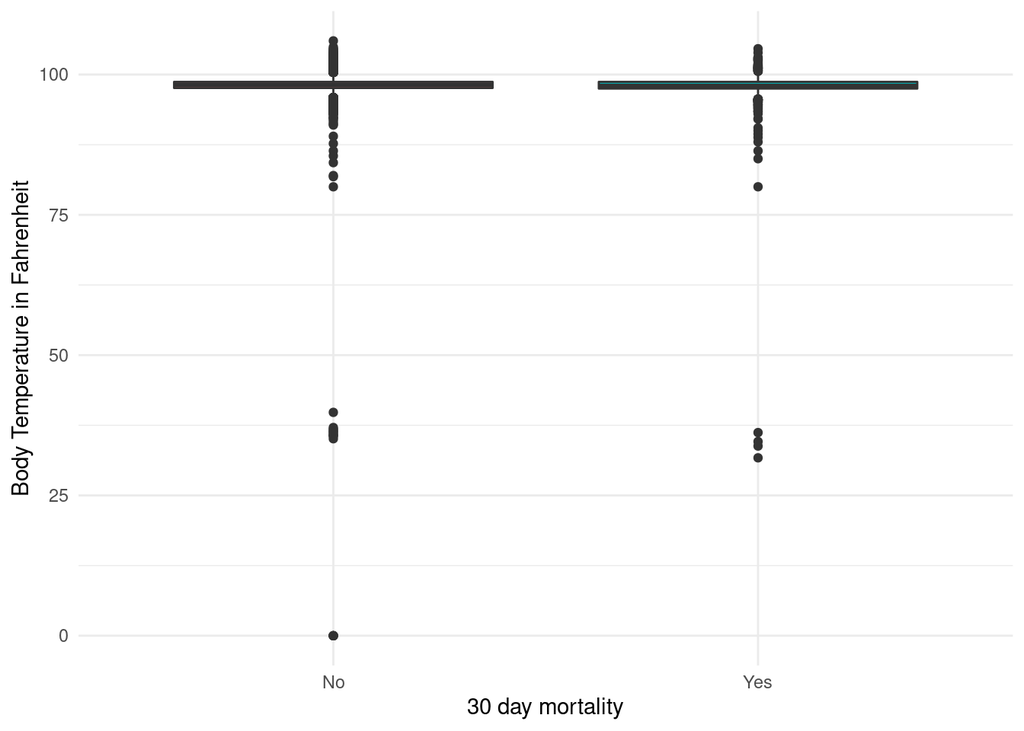

```r
mimic_icu_cohort %>%
  ggplot(mapping = aes(y = `body temperature in Fahrenheit`,
                       x = thirty_day_mort,
                       fill = thirty_day_mort)) +
  geom_boxplot() +
  labs(x = "30 day mortality", y = "Body Temperature in Fahrenheit") +
  theme_minimal() +
  theme(legend.position = "none")
```

```r
mimic_icu_cohort %>%
  group_by(thirty_day_mort) %>%
  summarise(n = n(),
            mean = mean(`body temperature in Fahrenheit`,
                        na.rm = TRUE),
            standard_deviation = sd(`body temperature in Fahrenheit`,
                                    na.rm = TRUE),
            min = min(`body temperature in Fahrenheit`, na.rm = TRUE),
            Q1 = quantile(`body temperature in Fahrenheit`, 0.25, na.rm = TRUE),
            median = median(`body temperature in Fahrenheit`,
                            na.rm = TRUE),
            Q3 = quantile(`body temperature in Fahrenheit`, 0.75, na.rm = TRUE),
            max = max(`body temperature in Fahrenheit`, na.rm = TRUE))
```

```
## # A tibble: 2 × 9
##   thirty_day_mort     n  mean standard_deviation   min    Q1 median    Q3   max
##   <chr>           <int> <dbl>              <dbl> <dbl> <dbl>  <dbl> <dbl> <dbl>
## 1 No              47855  98.1               2.96   0    97.6   98.2  98.7  106
## 2 Yes              5210  97.7               4.41  31.7  97.5   98    98.7  105.
```

- `thirty_day_mort` vs first ICU unit  
  **Solution:**

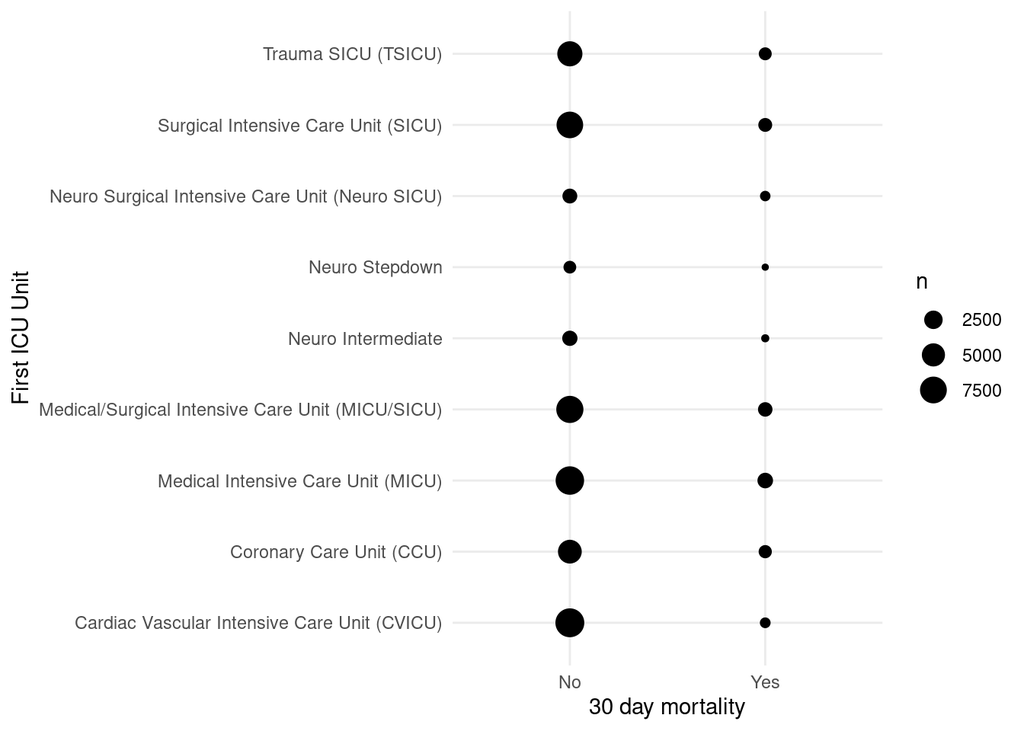

```r
mimic_icu_cohort %>%
  ggplot(mapping = aes(y = first_careunit, x = thirty_day_mort)) +
  geom_count() +
  labs(y = "First ICU Unit", x = "30 day mortality") +
  theme_minimal()
```

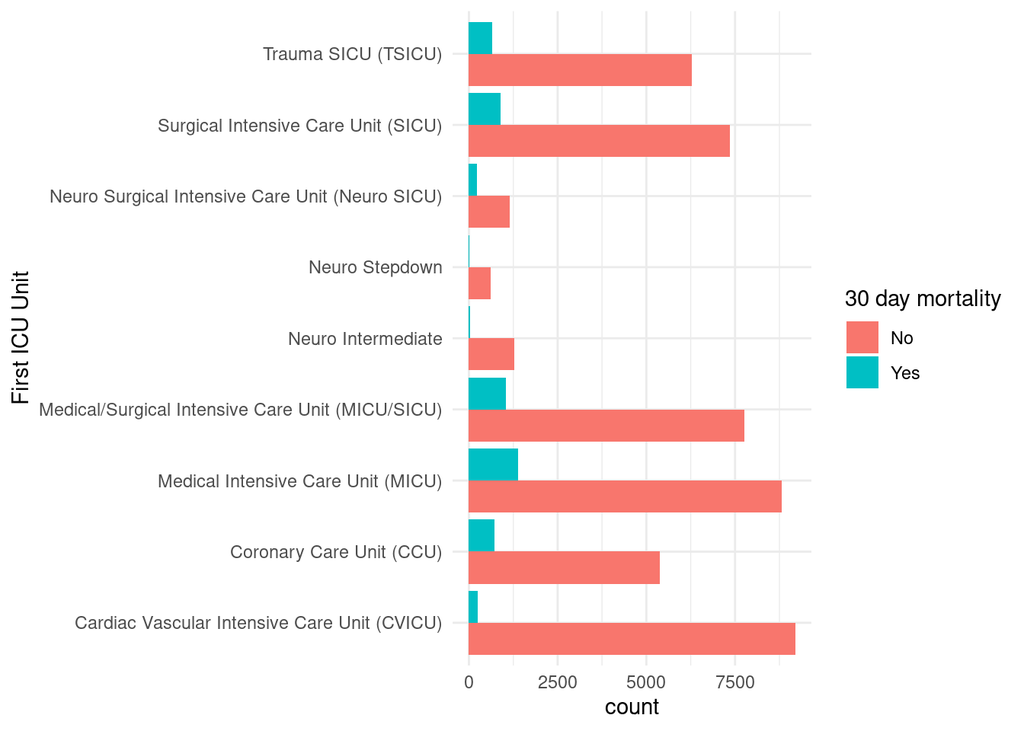

```r
mimic_icu_cohort %>%
  ggplot(mapping = aes(y = first_careunit, fill = thirty_day_mort)) +
  geom_bar(position="dodge") +
  labs(fill = "30 day mortality", y = "First ICU Unit") +
  theme_minimal()
```

```r
mimic_icu_cohort %>%
  group_by(first_careunit) %>%
  summarise(n = n(),
            `Died within 30 days` = sum(thirty_day_mort == "Yes"),
            Proportion_Yes = `Died within 30 days` / n,
            `Did not die within 30 days` = sum(thirty_day_mort == "No"),
            Proportion_No = `Did not die within 30 days` / n)
```

```
## # A tibble: 9 × 6
##   first_careunit           n `Died within 30 … Proportion_Yes `Did not die with…
##   <chr>                <int>             <int>          <dbl>              <int>
## 1 Cardiac Vascular In…  9448               257         0.0272               9191
## 2 Coronary Care Unit …  6098               716         0.117                5382
## 3 Medical Intensive C… 10207              1382         0.135                8825
## 4 Medical/Surgical In…  8819              1051         0.119                7768
## 5 Neuro Intermediate    1311                28         0.0214               1283
## 6 Neuro Stepdown         626                12         0.0192                614
## 7 Neuro Surgical Inte…  1380               223         0.162                1157
## 8 Surgical Intensive …  8238               883         0.107                7355
## 9 Trauma SICU (TSICU)   6938               658         0.0948               6280
## # … with 1 more variable: Proportion_No <dbl>
```